# Project: Identify Customer Segments

In this project, you will apply unsupervised learning techniques to identify segments of the population that form the core customer base for a mail-order sales company in Germany. These segments can then be used to direct marketing campaigns towards audiences that will have the highest expected rate of returns. The data that you will use has been provided by our partners at Bertelsmann Arvato Analytics, and represents a real-life data science task.

This notebook will help you complete this task by providing a framework within which you will perform your analysis steps. In each step of the project, you will see some text describing the subtask that you will perform, followed by one or more code cells for you to complete your work. **Feel free to add additional code and markdown cells as you go along so that you can explore everything in precise chunks.** The code cells provided in the base template will outline only the major tasks, and will usually not be enough to cover all of the minor tasks that comprise it.

It should be noted that while there will be precise guidelines on how you should handle certain tasks in the project, there will also be places where an exact specification is not provided. **There will be times in the project where you will need to make and justify your own decisions on how to treat the data.** These are places where there may not be only one way to handle the data. In real-life tasks, there may be many valid ways to approach an analysis task. One of the most important things you can do is clearly document your approach so that other scientists can understand the decisions you've made.

At the end of most sections, there will be a Markdown cell labeled **Discussion**. In these cells, you will report your findings for the completed section, as well as document the decisions that you made in your approach to each subtask. **Your project will be evaluated not just on the code used to complete the tasks outlined, but also your communication about your observations and conclusions at each stage.**

```python
# import libraries here; add more as necessary
import numpy as np
import pandas as pd
import matplotlib.pyplot as plt
import seaborn as sns
import operator
from sklearn.cluster import KMeans
from sklearn.preprocessing import Imputer
from sklearn.preprocessing import StandardScaler
from sklearn.decomposition import PCA
from collections import Counter
# magic word for producing visualizations in notebook
%matplotlib inline
```

### Step 0: Load the Data

There are four files associated with this project (not including this one):

- `Udacity_AZDIAS_Subset.csv`: Demographics data for the general population of Germany; 891211 persons (rows) x 85 features (columns).
- `Udacity_CUSTOMERS_Subset.csv`: Demographics data for customers of a mail-order company; 191652 persons (rows) x 85 features (columns).
- `Data_Dictionary.md`: Detailed information file about the features in the provided datasets.
- `AZDIAS_Feature_Summary.csv`: Summary of feature attributes for demographics data; 85 features (rows) x 4 columns

Each row of the demographics files represents a single person, but also includes information outside of individuals, including information about their household, building, and neighborhood. You will use this information to cluster the general population into groups with similar demographic properties. Then, you will see how the people in the customers dataset fit into those created clusters. The hope here is that certain clusters are over-represented in the customers data, as compared to the general population; those over-represented clusters will be assumed to be part of the core userbase. This information can then be used for further applications, such as targeting for a marketing campaign.

To start off with, load in the demographics data for the general population into a pandas DataFrame, and do the same for the feature attributes summary. Note for all of the `.csv` data files in this project: they're semicolon (`;`) delimited, so you'll need an additional argument in your [`read_csv()`](https://pandas.pydata.org/pandas-docs/stable/generated/pandas.read_csv.html) call to read in the data properly. Also, considering the size of the main dataset, it may take some time for it to load completely.

Once the dataset is loaded, it's recommended that you take a little bit of time just browsing the general structure of the dataset and feature summary file. You'll be getting deep into the innards of the cleaning in the first major step of the project, so gaining some general familiarity can help you get your bearings.

```python
# Load in the general demographics data.
azdias = pd.read_csv('./Udacity_AZDIAS_Subset.csv',sep=';')

# Load in the feature summary file.
feat_info = pd.read_csv('./AZDIAS_Feature_Summary.csv',sep=';',
                        converters={'missing_or_unknown': lambda x: x.strip("[]").split(",")})
```

```python
# Check the structure of the data after it's loaded (e.g. print the number of
# rows and columns, print the first few rows).
azdias.head()
```

|  | AGER_TYP | ALTERSKATEGORIE_GROB | ANREDE_KZ | CJT_GESAMTTYP | FINANZ_MINIMALIST | FINANZ_SPARER | FINANZ_VORSORGER | FINANZ_ANLEGER | FINANZ_UNAUFFAELLIGER | FINANZ_HAUSBAUER | ... | PLZ8_ANTG1 | PLZ8_ANTG2 | PLZ8_ANTG3 | PLZ8_ANTG4 | PLZ8_BAUMAX | PLZ8_HHZ | PLZ8_GBZ | ARBEIT | ORTSGR_KLS9 | RELAT_AB |
| --- | --- | --- | --- | --- | --- | --- | --- | --- | --- | --- | --- | --- | --- | --- | --- | --- | --- | --- | --- | --- | --- |
| 0 | -1 | 2 | 1 | 2.0 | 3 | 4 | 3 | 5 | 5 | 3 | ... | NaN | NaN | NaN | NaN | NaN | NaN | NaN | NaN | NaN | NaN |
| 1 | -1 | 1 | 2 | 5.0 | 1 | 5 | 2 | 5 | 4 | 5 | ... | 2.0 | 3.0 | 2.0 | 1.0 | 1.0 | 5.0 | 4.0 | 3.0 | 5.0 | 4.0 |
| 2 | -1 | 3 | 2 | 3.0 | 1 | 4 | 1 | 2 | 3 | 5 | ... | 3.0 | 3.0 | 1.0 | 0.0 | 1.0 | 4.0 | 4.0 | 3.0 | 5.0 | 2.0 |
| 3 | 2 | 4 | 2 | 2.0 | 4 | 2 | 5 | 2 | 1 | 2 | ... | 2.0 | 2.0 | 2.0 | 0.0 | 1.0 | 3.0 | 4.0 | 2.0 | 3.0 | 3.0 |
| 4 | -1 | 3 | 1 | 5.0 | 4 | 3 | 4 | 1 | 3 | 2 | ... | 2.0 | 4.0 | 2.0 | 1.0 | 2.0 | 3.0 | 3.0 | 4.0 | 6.0 | 5.0 |

5 rows × 85 columns

> **Tip**: Add additional cells to keep everything in reasonably-sized chunks! Keyboard shortcut `esc --> a` (press escape to enter command mode, then press the 'A' key) adds a new cell before the active cell, and `esc --> b` adds a new cell after the active cell. If you need to convert an active cell to a markdown cell, use `esc --> m` and to convert to a code cell, use `esc --> y`.

## Step 1: Preprocessing

### Step 1.1: Assess Missing Data

The feature summary file contains a summary of properties for each demographics data column. You will use this file to help you make cleaning decisions during this stage of the project. First of all, you should assess the demographics data in terms of missing data. Pay attention to the following points as you perform your analysis, and take notes on what you observe. Make sure that you fill in the **Discussion** cell with your findings and decisions at the end of each step that has one!

#### Step 1.1.1: Convert Missing Value Codes to NaNs

The fourth column of the feature attributes summary (loaded in above as `feat_info`) documents the codes from the data dictionary that indicate missing or unknown data. While the file encodes this as a list (e.g. `[-1,0]`), this will get read in as a string object. You'll need to do a little bit of parsing to make use of it to identify and clean the data. Convert data that matches a 'missing' or 'unknown' value code into a numpy NaN value. You might want to see how much data takes on a 'missing' or 'unknown' code, and how much data is naturally missing, as a point of interest.

**As one more reminder, you are encouraged to add additional cells to break up your analysis into manageable chunks.**

#### Step 1.1.2: Assess Missing Data in Each Column

How much missing data is present in each column? There are a few columns that are outliers in terms of the proportion of values that are missing. You will want to use matplotlib's [`hist()`](https://matplotlib.org/api/_as_gen/matplotlib.pyplot.hist.html) function to visualize the distribution of missing value counts to find these columns. Identify and document these columns. While some of these columns might have justifications for keeping or re-encoding the data, for this project you should just remove them from the dataframe. (Feel free to make remarks about these outlier columns in the discussion, however!)

For the remaining features, are there any patterns in which columns have, or share, missing data?

```python
def convert(s):
    try:
        return int(s)
    except ValueError:
        return s

def replace_unknowns(df, column_name, unknown_vals):
    for unk in unknown_vals:
        if unk and unk != '-1':
            unk = convert(unk)
            df.loc[df[column_name] == unk, column_name] = -1

def get_unknowns(col):
    return feat_info[feat_info['attribute'] ==  col]['missing_or_unknown'].values[0]

def percent_missing(df, col_name):
    count_unknowns = sum(df[col_name] == -1)
    count_missing = df[col_name].isnull().sum()
    perc_unknown = 100*count_unknowns/df.shape[0]
    perc_missing = 100*count_missing/df.shape[0]
    print("{}\n\tUnknown: {:.1f}".format(col_name,perc_unknown))
    print("\tMissing: {:.1f}\n".format(perc_missing))
```

- Replace other types of unknown flags with -1

```python
all_cols = list(azdias)
```

```python
for col in all_cols:
    unks = get_unknowns(col)
    if unks:
        replace_unknowns(azdias, col, unks)
```

```python
for col in all_cols:
    percent_missing(azdias,col)
```

```
AGER_TYP
	Unknown: 77.0
	Missing: 0.0

ALTERSKATEGORIE_GROB
	Unknown: 0.3
	Missing: 0.0

ANREDE_KZ
	Unknown: 0.0
	Missing: 0.0

CJT_GESAMTTYP
	Unknown: 0.0
	Missing: 0.5

FINANZ_MINIMALIST
	Unknown: 0.0
	Missing: 0.0

FINANZ_SPARER
	Unknown: 0.0
	Missing: 0.0

FINANZ_VORSORGER
	Unknown: 0.0
	Missing: 0.0

FINANZ_ANLEGER
	Unknown: 0.0
	Missing: 0.0

FINANZ_UNAUFFAELLIGER
	Unknown: 0.0
	Missing: 0.0

FINANZ_HAUSBAUER
	Unknown: 0.0
	Missing: 0.0

```

[output cut: 284 more lines]

```
PLZ8_GBZ
	Unknown: 0.0
	Missing: 13.1

ARBEIT
	Unknown: 0.0
	Missing: 10.9

ORTSGR_KLS9
	Unknown: 0.0
	Missing: 10.9

RELAT_AB
	Unknown: 0.0
	Missing: 10.9
```

The amount of missing/unknown values is low for most columns with these initial stand outs:

- AGER_TYP (elderly_activity): 77%
- TITEL_KZ (acedemica title): 91.5%
- KK_KUNDENTYP (consumer_pattern): 65.6% missing

#### Convert missing/unknowns to NaN:

```python
df_clean = azdias.replace(-1, np.NaN)
df_clean.head()
```

|  | AGER_TYP | ALTERSKATEGORIE_GROB | ANREDE_KZ | CJT_GESAMTTYP | FINANZ_MINIMALIST | FINANZ_SPARER | FINANZ_VORSORGER | FINANZ_ANLEGER | FINANZ_UNAUFFAELLIGER | FINANZ_HAUSBAUER | ... | PLZ8_ANTG1 | PLZ8_ANTG2 | PLZ8_ANTG3 | PLZ8_ANTG4 | PLZ8_BAUMAX | PLZ8_HHZ | PLZ8_GBZ | ARBEIT | ORTSGR_KLS9 | RELAT_AB |
| --- | --- | --- | --- | --- | --- | --- | --- | --- | --- | --- | --- | --- | --- | --- | --- | --- | --- | --- | --- | --- | --- |
| 0 | NaN | 2.0 | 1 | 2.0 | 3 | 4 | 3 | 5 | 5 | 3 | ... | NaN | NaN | NaN | NaN | NaN | NaN | NaN | NaN | NaN | NaN |
| 1 | NaN | 1.0 | 2 | 5.0 | 1 | 5 | 2 | 5 | 4 | 5 | ... | 2.0 | 3.0 | 2.0 | 1.0 | 1.0 | 5.0 | 4.0 | 3.0 | 5.0 | 4.0 |
| 2 | NaN | 3.0 | 2 | 3.0 | 1 | 4 | 1 | 2 | 3 | 5 | ... | 3.0 | 3.0 | 1.0 | 0.0 | 1.0 | 4.0 | 4.0 | 3.0 | 5.0 | 2.0 |
| 3 | 2.0 | 4.0 | 2 | 2.0 | 4 | 2 | 5 | 2 | 1 | 2 | ... | 2.0 | 2.0 | 2.0 | 0.0 | 1.0 | 3.0 | 4.0 | 2.0 | 3.0 | 3.0 |
| 4 | NaN | 3.0 | 1 | 5.0 | 4 | 3 | 4 | 1 | 3 | 2 | ... | 2.0 | 4.0 | 2.0 | 1.0 | 2.0 | 3.0 | 3.0 | 4.0 | 6.0 | 5.0 |

5 rows × 85 columns

#### Spot check to make sure things still seem good after replacing values:

```python
#class_fine had 11% missing
print(100*sum(df_clean['CAMEO_DEU_2015'].isnull())/df_clean.shape[0])

#risk_type had 12.5% unknown
print(100*sum(df_clean['VERS_TYP'].isnull())/df_clean.shape[0])

#gender had 0 missing and unknown
print(100*sum(df_clean['ANREDE_KZ'].isnull())/df_clean.shape[0])
```

```
11.1478522162
12.4768155149
0.0
```

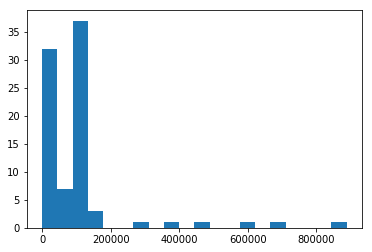

```python
# Investigate patterns in the amount of missing data in each column.
nans = df_clean.isnull().sum()
plt.hist(nans,20)
```

##### Same thing, but with percentages

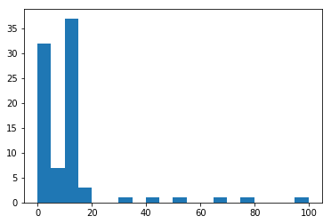

```python
nans = 100*df_clean.isnull().sum()/df_clean.shape[0]
plt.hist(nans,20)
```

```python
for col in all_cols:
    perc = 100 * df_clean[col].isnull().sum() / df_clean.shape[0]
    if perc > 20:
        print(col)
        print(perc)
```

```
AGER_TYP
76.9554352961
GEBURTSJAHR
44.0202822869
TITEL_KZ
99.7576358726
ALTER_HH
34.8136994079
KK_KUNDENTYP
65.5967487301
KBA05_BAUMAX
53.4686682652
```

```python
# Remove the outlier columns from the dataset. (You'll perform other data
# engineering tasks such as re-encoding and imputation later.)

dropped_columns = ['AGER_TYP', 'GEBURTSJAHR', 'TITEL_KZ', 'ALTER_HH', 'KK_KUNDENTYP', 'KBA05_BAUMAX']
df_clean.drop(dropped_columns, axis=1, inplace=True)
all_cols = list(df_clean)
```

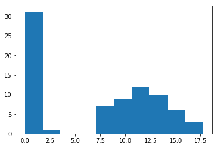

```python
nans = 100 * df_clean.isnull().sum() / df_clean.shape[0]
plt.hist(nans,10)
```

#### Features with more than 10% missing/unknown values

```python
for col in all_cols:
    perc = 100 * df_clean[col].isnull().sum() / df_clean.shape[0]
    if perc > 10:
        print("{}:\t{:.1f}".format(col, perc))
```

```
HEALTH_TYP:	12.5
LP_LEBENSPHASE_FEIN:	11.0
LP_LEBENSPHASE_GROB:	10.6
NATIONALITAET_KZ:	12.2
PRAEGENDE_JUGENDJAHRE:	12.1
SHOPPER_TYP:	12.5
VERS_TYP:	12.5
W_KEIT_KIND_HH:	16.6
ANZ_HAUSHALTE_AKTIV:	11.2
ANZ_HH_TITEL:	10.9
GEBAEUDETYP:	10.5
MIN_GEBAEUDEJAHR:	10.5
OST_WEST_KZ:	10.5
WOHNLAGE:	10.5
CAMEO_DEUG_2015:	11.1
CAMEO_DEU_2015:	11.1
CAMEO_INTL_2015:	11.1
KBA05_ANTG1:	15.0
KBA05_ANTG2:	15.0
KBA05_ANTG3:	15.0
KBA05_ANTG4:	15.0
KBA05_GBZ:	15.0
BALLRAUM:	10.5
EWDICHTE:	10.5
INNENSTADT:	10.5
GEBAEUDETYP_RASTER:	10.5
KKK:	17.7
MOBI_REGIO:	15.0
REGIOTYP:	17.7
KBA13_ANZAHL_PKW:	11.9
PLZ8_ANTG1:	13.1
PLZ8_ANTG2:	13.1
PLZ8_ANTG3:	13.1
PLZ8_ANTG4:	13.1
PLZ8_BAUMAX:	13.1
PLZ8_HHZ:	13.1
PLZ8_GBZ:	13.1
ARBEIT:	10.9
ORTSGR_KLS9:	10.9
RELAT_AB:	10.9
```

#### Discussion 1.1.2: Assess Missing Data in Each Column

##### My Observations

- AGER_TYP, TITEL_KZ, GEBURTSJAHR, ALTER_HH, KK_KUNDENTYP, and KBA05_BAUMAX were outliers in terms of the percentage of missing or unknown data. They all had over 20% of their data missing respectively, and so I deleted these columns from the dataset.
- There's a large number of features (roughly half) that are missing 8% to 14% of their values. Anything over 10% seems like a lot of data to be missing, but I'm leaving these features in because they may be important for getting useful clustering.

#### Step 1.1.3: Assess Missing Data in Each Row

Now, you'll perform a similar assessment for the rows of the dataset. How much data is missing in each row? As with the columns, you should see some groups of points that have a very different numbers of missing values. Divide the data into two subsets: one for data points that are above some threshold for missing values, and a second subset for points below that threshold.

In order to know what to do with the outlier rows, we should see if the distribution of data values on columns that are not missing data (or are missing very little data) are similar or different between the two groups. Select at least five of these columns and compare the distribution of values.

- You can use seaborn's [`countplot()`](https://seaborn.pydata.org/generated/seaborn.countplot.html) function to create a bar chart of code frequencies and matplotlib's [`subplot()`](https://matplotlib.org/api/_as_gen/matplotlib.pyplot.subplot.html) function to put bar charts for the two subplots side by side.
- To reduce repeated code, you might want to write a function that can perform this comparison, taking as one of its arguments a column to be compared.

Depending on what you observe in your comparison, this will have implications on how you approach your conclusions later in the analysis. If the distributions of non-missing features look similar between the data with many missing values and the data with few or no missing values, then we could argue that simply dropping those points from the analysis won't present a major issue. On the other hand, if the data with many missing values looks very different from the data with few or no missing values, then we should make a note on those data as special. Make sure you report your observations in the discussion section. **Either way, you should continue your analysis below using just the subset of the data with few or no missing values.**

```python
row_nans = df_clean.isnull().sum(axis=1)
```

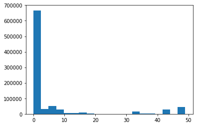

```python
# How much data is missing in each row of the dataset?
row_nans = df_clean.isnull().sum(axis=1)
plt.hist(row_nans,20)
```

ANREDE_KZ Unknown: 0.0 Missing: 0.0

FINANZTYP Unknown: 0.0 Missing: 0.0

FINANZ_MINIMALIST Unknown: 0.0 Missing: 0.0

SEMIO_RAT Unknown: 0.0 Missing: 0.0

```python
# Compare the distribution of values for at least five columns where there are
# no or few missing values, between the two subsets.

def distribution_charts(high_missing, low_missing):
    sns.set(style="darkgrid")
    fig, ax =plt.subplots(5,2,figsize=(15,15))
    fig.subplots_adjust(hspace=0.5)

    fonts = fontdict={'fontsize':20,'fontweight':'bold'}
    ax[0,0].set_title("High Amount Missing Data",fontdict=fonts)
    ax[0,1].set_title("Low Amount Missing Data",fontdict=fonts)

    sns.countplot(x='ALTERSKATEGORIE_GROB',data=high_missing, ax=ax[0,0])
    sns.countplot(x='ALTERSKATEGORIE_GROB',data=low_missing, ax=ax[0,1])

    sns.countplot(x='ANREDE_KZ',data=high_missing, ax=ax[1,0])
    sns.countplot(x='ANREDE_KZ',data=low_missing, ax=ax[1,1])

    sns.countplot(x='FINANZTYP',data=high_missing, ax=ax[2,0])
    sns.countplot(x='FINANZTYP',data=low_missing, ax=ax[2,1])

    sns.countplot(x='FINANZ_MINIMALIST',data=high_missing, ax=ax[3,0])
    sns.countplot(x='FINANZ_MINIMALIST',data=low_missing, ax=ax[3,1])

    sns.countplot(x='SEMIO_RAT',data=high_missing, ax=ax[4,0])
    sns.countplot(x='SEMIO_RAT',data=low_missing, ax=ax[4,1])
```

```
774743
116478
```

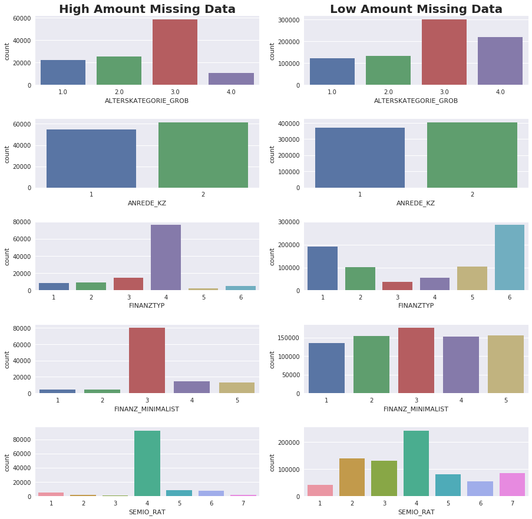

```python
# Write code to divide the data into two subsets based on the number of missing
# values in each row.
df_low_missing = df_clean[df_clean.isnull().sum(axis=1)<10]
df_high_missing = df_clean[df_clean.isnull().sum(axis=1)>=10]

print(df_low_missing.shape[0])
print(df_high_missing.shape[0])

distribution_charts(df_high_missing, df_low_missing)
```

```
798061
93160
```

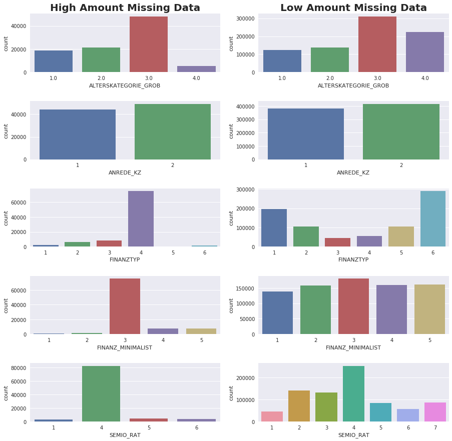

```python
# Write code to divide the data into two subsets based on the number of missing
# values in each row.
df_low_missing = df_clean[df_clean.isnull().sum(axis=1)<30]
df_high_missing = df_clean[df_clean.isnull().sum(axis=1)>=30]

print(df_low_missing.shape[0])
print(df_high_missing.shape[0])

distribution_charts(df_high_missing, df_low_missing)
```

#### Discussion 1.1.3: Assess Missing Data in Each Row

I did this twice with different splits of data. The first put the split at rows missing 10 or more values. The second at rows missing 30 or more values. I wanted to see if there was a significant differnce between the two splits. There really wasn't according to the charts.

The data with missing values (either >10 or >30) *does* show some differences most significantly for the 'FINANZTYPE', 'FIANZ_MINIMALIST', and 'SEMIO_RAT' features. These have a different distribution in responses compared to the rows with little missing data. They show that unlike the rows with little missing data, the responses are overwhelmingly in a single category for the three features: '4', '3', and '4' respetively.

Using the handly data dictionary, we see these soorespond to:

- Financial Type: 'be prepared (VORSORGER)'
- Financial Typology= Low financial interest: 'average'
- Personality Typology= Rational: 'average affinity'

So, those people that have high amounts of missing data also seem to be more likely to be of the 'be prepared' financial type, and more likely to score average on 'low financial interest' and 'rational' personality type.

Based on this, I believe it is important to not exclude these rows as the participants seem to be different in financial and personality traits from the other data.

### Step 1.2: Select and Re-Encode Features

Checking for missing data isn't the only way in which you can prepare a dataset for analysis. Since the unsupervised learning techniques to be used will only work on data that is encoded numerically, you need to make a few encoding changes or additional assumptions to be able to make progress. In addition, while almost all of the values in the dataset are encoded using numbers, not all of them represent numeric values. Check the third column of the feature summary (`feat_info`) for a summary of types of measurement.

- For numeric and interval data, these features can be kept without changes.
- Most of the variables in the dataset are ordinal in nature. While ordinal values may technically be non-linear in spacing, make the simplifying assumption that the ordinal variables can be treated as being interval in nature (that is, kept without any changes).
- Special handling may be necessary for the remaining two variable types: categorical, and 'mixed'.

In the first two parts of this sub-step, you will perform an investigation of the categorical and mixed-type features and make a decision on each of them, whether you will keep, drop, or re-encode each. Then, in the last part, you will create a new data frame with only the selected and engineered columns.

Data wrangling is often the trickiest part of the data analysis process, and there's a lot of it to be done here. But stick with it: once you're done with this step, you'll be ready to get to the machine learning parts of the project!

```python
# How many features are there of each data type?
types = feat_info['type'].unique()
for atype in types:
    print("{}: {}".format(atype,(feat_info['type'] == atype).sum()))
```

```
categorical: 21
ordinal: 49
numeric: 7
mixed: 7
interval: 1
```

# Step 1.2.1: Re-Encode Categorical Features

For categorical data, you would ordinarily need to encode the levels as dummy variables. Depending on the number of categories, perform one of the following:

- For binary (two-level) categoricals that take numeric values, you can keep them without needing to do anything.
- There is one binary variable that takes on non-numeric values. For this one, you need to re-encode the values as numbers or create a dummy variable.
- For multi-level categoricals (three or more values), you can choose to encode the values using multiple dummy variables (e.g. via [OneHotEncoder](http://scikit-learn.org/stable/modules/generated/sklearn.preprocessing.OneHotEncoder.html)), or (to keep things straightforward) just drop them from the analysis. As always, document your choices in the Discussion section.

```python
# Assess categorical variables: which are binary, which are multi-level, and
# which one needs to be re-encoded?

cat_attributes = feat_info[feat_info['type']=='categorical']['attribute']
print(cat_attributes)
```

```
0             AGER_TYP
2            ANREDE_KZ
3        CJT_GESAMTTYP
10           FINANZTYP
12     GFK_URLAUBERTYP
13    GREEN_AVANTGARDE
17     LP_FAMILIE_FEIN
18     LP_FAMILIE_GROB
19      LP_STATUS_FEIN
20      LP_STATUS_GROB
21    NATIONALITAET_KZ
38         SHOPPER_TYP
39             SOHO_KZ
40            TITEL_KZ
41            VERS_TYP
42            ZABEOTYP
47        KK_KUNDENTYP
52         GEBAEUDETYP
55         OST_WEST_KZ
57     CAMEO_DEUG_2015
58      CAMEO_DEU_2015
Name: attribute, dtype: object
```

```python
non_numeric_binary = ['OST_WEST_KZ']
binary = ['ANREDE_KZ','GREEN_AVANTGARDE','SOHO_KZ','VERS_TYP']
multi = ['CJT_GESAMTTYP','FINANZTYP','GFK_URLAUBERTYP','LP_FAMILIE_FEIN',
         'LP_FAMILIE_GROB','LP_STATUS_FEIN','LP_STATUS_GROB','NATIONALITAET_KZ',
        'SHOPPER_TYP','ZABEOTYP','GEBAEUDETYP','CAMEO_DEUG_2015','CAMEO_DEU_2015']
```

```python
#Re-encode non-numeric binary:
df_clean['OST_WEST_KZ'] = df_clean['OST_WEST_KZ'].map({'O': 0, 'W': 1})
```

```python
#Look at the amout of missing data in multi-categorical columns to help decide whether to drop them:
for col in multi:
    percent_missing(df_clean,col)
```

```
CJT_GESAMTTYP
	Unknown: 0.0
	Missing: 0.5

FINANZTYP
	Unknown: 0.0
	Missing: 0.0

GFK_URLAUBERTYP
	Unknown: 0.0
	Missing: 0.5

LP_FAMILIE_FEIN
	Unknown: 0.0
	Missing: 8.7

LP_FAMILIE_GROB
	Unknown: 0.0
	Missing: 8.7

LP_STATUS_FEIN
	Unknown: 0.0
	Missing: 0.5

LP_STATUS_GROB
	Unknown: 0.0
	Missing: 0.5

NATIONALITAET_KZ
	Unknown: 0.0
	Missing: 12.2

SHOPPER_TYP
	Unknown: 0.0
	Missing: 12.5

ZABEOTYP
	Unknown: 0.0
	Missing: 0.0

GEBAEUDETYP
	Unknown: 0.0
	Missing: 10.5

CAMEO_DEUG_2015
	Unknown: 0.0
	Missing: 11.1

CAMEO_DEU_2015
	Unknown: 0.0
	Missing: 11.1
```

```python
#Drop columns with high missing data
dropped_columns_multi_cat = ['CAMEO_DEU_2015', 'CAMEO_DEUG_2015','SHOPPER_TYP','GEBAEUDETYP','NATIONALITAET_KZ']
df_clean.drop(dropped_columns_multi_cat, axis=1, inplace=True)
```

```python
multi = ['CJT_GESAMTTYP','FINANZTYP','GFK_URLAUBERTYP','LP_FAMILIE_FEIN',
         'LP_FAMILIE_GROB','LP_STATUS_FEIN','LP_STATUS_GROB','ZABEOTYP']
```

```python
df_encoded = pd.get_dummies(df_clean,dummy_na=True,columns=multi)
```

```python
df_encoded.head()
```

|  | ALTERSKATEGORIE_GROB | ANREDE_KZ | FINANZ_MINIMALIST | FINANZ_SPARER | FINANZ_VORSORGER | FINANZ_ANLEGER | FINANZ_UNAUFFAELLIGER | FINANZ_HAUSBAUER | GREEN_AVANTGARDE | HEALTH_TYP | ... | LP_STATUS_GROB_4.0 | LP_STATUS_GROB_5.0 | LP_STATUS_GROB_nan | ZABEOTYP_1.0 | ZABEOTYP_2.0 | ZABEOTYP_3.0 | ZABEOTYP_4.0 | ZABEOTYP_5.0 | ZABEOTYP_6.0 | ZABEOTYP_nan |
| --- | --- | --- | --- | --- | --- | --- | --- | --- | --- | --- | --- | --- | --- | --- | --- | --- | --- | --- | --- | --- | --- |
| 0 | 2.0 | 1 | 3 | 4 | 3 | 5 | 5 | 3 | 0 | NaN | ... | 0 | 0 | 0 | 0 | 0 | 1 | 0 | 0 | 0 | 0 |
| 1 | 1.0 | 2 | 1 | 5 | 2 | 5 | 4 | 5 | 0 | 3.0 | ... | 0 | 0 | 0 | 0 | 0 | 0 | 0 | 1 | 0 | 0 |
| 2 | 3.0 | 2 | 1 | 4 | 1 | 2 | 3 | 5 | 1 | 3.0 | ... | 0 | 0 | 0 | 0 | 0 | 0 | 0 | 1 | 0 | 0 |
| 3 | 4.0 | 2 | 4 | 2 | 5 | 2 | 1 | 2 | 0 | 2.0 | ... | 1 | 0 | 0 | 0 | 0 | 1 | 0 | 0 | 0 | 0 |
| 4 | 3.0 | 1 | 4 | 3 | 4 | 1 | 3 | 2 | 0 | 3.0 | ... | 0 | 0 | 0 | 0 | 0 | 0 | 1 | 0 | 0 | 0 |

5 rows × 135 columns

#### Discussion 1.2.1: Re-Encode Categorical Features

- I re-encoded the binary 'OST_WEST_KZ' feature from 'O','W' to 0, 1
- For the multi-categorical features, I decided to drop the columns with high missing values (>10%):
  - CAMEO_DEU_2015, CAMEO_DEUG_2015, SHOPPER_TYP, GEBAEUDETYP, NATIONALITAET_KZ
- The other multi-categorical features were one-hot encoded using pandas.get_dummmies with the NaN values converted into their own column for each type.

#### Step 1.2.2: Engineer Mixed-Type Features

There are a handful of features that are marked as "mixed" in the feature summary that require special treatment in order to be included in the analysis. There are two in particular that deserve attention; the handling of the rest are up to your own choices:

- "PRAEGENDE_JUGENDJAHRE" combines information on three dimensions: generation by decade, movement (mainstream vs. avantgarde), and nation (east vs. west). While there aren't enough levels to disentangle east from west, you should create two new variables to capture the other two dimensions: an interval-type variable for decade, and a binary variable for movement.
- "CAMEO_INTL_2015" combines information on two axes: wealth and life stage. Break up the two-digit codes by their 'tens'-place and 'ones'-place digits into two new ordinal variables (which, for the purposes of this project, is equivalent to just treating them as their raw numeric values).
- If you decide to keep or engineer new features around the other mixed-type features, make sure you note your steps in the Discussion section.

Be sure to check `Data_Dictionary.md` for the details needed to finish these tasks.

```python
# Investigate "PRAEGENDE_JUGENDJAHRE" and engineer two new variables.

# interval-type variable for decade, and a binary variable for movement.
# youth_decade values=1(40s),2(50s),3(60s),4(70s),5(80s),6(90s)  avantgarde values = 1, 0
# - 1: 40s - war years (Mainstream, E+W)
# -  2: 40s - reconstruction years (Avantgarde, E+W)
# -  3: 50s - economic miracle (Mainstream, E+W)
# -  4: 50s - milk bar / Individualisation (Avantgarde, E+W)
# -  5: 60s - economic miracle (Mainstream, E+W)
# -  6: 60s - generation 68 / student protestors (Avantgarde, W)
# -  7: 60s - opponents to the building of the Wall (Avantgarde, E)
# -  8: 70s - family orientation (Mainstream, E+W)
# -  9: 70s - peace movement (Avantgarde, E+W)
# - 10: 80s - Generation Golf (Mainstream, W)
# - 11: 80s - ecological awareness (Avantgarde, W)
# - 12: 80s - FDJ / communist party youth organisation (Mainstream, E)
# - 13: 80s - Swords into ploughshares (Avantgarde, E)
# - 14: 90s - digital media kids (Mainstream, E+W)
# - 15: 90s - ecological awareness (Avantgarde, E+W)

avantgarde_map = [2,4,6,7,9,11,13,15]
generational_map = {1:1, 2:1, 3:2, 4:2, 5:3, 6:3, 7:3, 8:4, 9:4,
                    10:5, 11:5, 12:5, 13:5, 14:6, 15: 6}
```

```python
# Get counts before engineering
df_encoded['PRAEGENDE_JUGENDJAHRE'].value_counts()
```

```
14.0    188697
8.0     145988
5.0      86416
10.0     85808
3.0      55195
15.0     42547
11.0     35752
9.0      33570
6.0      25652
12.0     24446
1.0      21282
4.0      20451
2.0       7479
13.0      5764
7.0       4010
Name: PRAEGENDE_JUGENDJAHRE, dtype: int64
```

```python
#add new column for avantgarde. 1 = avantgard, 0=mainstream

df_encoded['avantgarde'] = np.where(df_encoded['PRAEGENDE_JUGENDJAHRE'].isin(avantgarde_map), 1, 0)
```

```python
# map values in 'PRAEGENDE_JUGENDJAHRE' for generation of youth
# 1 = 40s
# 2 = 50s
# 3 = 60s
# 4 = 70s
# 5 = 80s
# 6 = 90s

df_encoded['generation'] =  df_encoded['PRAEGENDE_JUGENDJAHRE'].map(generational_map)
df_encoded.head()
```

|  | ALTERSKATEGORIE_GROB | ANREDE_KZ | FINANZ_MINIMALIST | FINANZ_SPARER | FINANZ_VORSORGER | FINANZ_ANLEGER | FINANZ_UNAUFFAELLIGER | FINANZ_HAUSBAUER | GREEN_AVANTGARDE | HEALTH_TYP | ... | LP_STATUS_GROB_nan | ZABEOTYP_1.0 | ZABEOTYP_2.0 | ZABEOTYP_3.0 | ZABEOTYP_4.0 | ZABEOTYP_5.0 | ZABEOTYP_6.0 | ZABEOTYP_nan | avantgarde | generation |
| --- | --- | --- | --- | --- | --- | --- | --- | --- | --- | --- | --- | --- | --- | --- | --- | --- | --- | --- | --- | --- | --- |
| 0 | 2.0 | 1 | 3 | 4 | 3 | 5 | 5 | 3 | 0 | NaN | ... | 0 | 0 | 0 | 1 | 0 | 0 | 0 | 0 | 0 | NaN |
| 1 | 1.0 | 2 | 1 | 5 | 2 | 5 | 4 | 5 | 0 | 3.0 | ... | 0 | 0 | 0 | 0 | 0 | 1 | 0 | 0 | 0 | 6.0 |
| 2 | 3.0 | 2 | 1 | 4 | 1 | 2 | 3 | 5 | 1 | 3.0 | ... | 0 | 0 | 0 | 0 | 0 | 1 | 0 | 0 | 1 | 6.0 |
| 3 | 4.0 | 2 | 4 | 2 | 5 | 2 | 1 | 2 | 0 | 2.0 | ... | 0 | 0 | 0 | 1 | 0 | 0 | 0 | 0 | 0 | 4.0 |
| 4 | 3.0 | 1 | 4 | 3 | 4 | 1 | 3 | 2 | 0 | 3.0 | ... | 0 | 0 | 0 | 0 | 1 | 0 | 0 | 0 | 0 | 4.0 |

5 rows × 137 columns

```python
df_encoded.drop('PRAEGENDE_JUGENDJAHRE', axis=1,inplace=True)
dropped_columns_replaced =  ['PRAEGENDE_JUGENDJAHRE']
all_cols = list(df_encoded)
```

```python
df_encoded.head()
```

|  | ALTERSKATEGORIE_GROB | ANREDE_KZ | FINANZ_MINIMALIST | FINANZ_SPARER | FINANZ_VORSORGER | FINANZ_ANLEGER | FINANZ_UNAUFFAELLIGER | FINANZ_HAUSBAUER | GREEN_AVANTGARDE | HEALTH_TYP | ... | LP_STATUS_GROB_nan | ZABEOTYP_1.0 | ZABEOTYP_2.0 | ZABEOTYP_3.0 | ZABEOTYP_4.0 | ZABEOTYP_5.0 | ZABEOTYP_6.0 | ZABEOTYP_nan | avantgarde | generation |
| --- | --- | --- | --- | --- | --- | --- | --- | --- | --- | --- | --- | --- | --- | --- | --- | --- | --- | --- | --- | --- | --- |
| 0 | 2.0 | 1 | 3 | 4 | 3 | 5 | 5 | 3 | 0 | NaN | ... | 0 | 0 | 0 | 1 | 0 | 0 | 0 | 0 | 0 | NaN |
| 1 | 1.0 | 2 | 1 | 5 | 2 | 5 | 4 | 5 | 0 | 3.0 | ... | 0 | 0 | 0 | 0 | 0 | 1 | 0 | 0 | 0 | 6.0 |
| 2 | 3.0 | 2 | 1 | 4 | 1 | 2 | 3 | 5 | 1 | 3.0 | ... | 0 | 0 | 0 | 0 | 0 | 1 | 0 | 0 | 1 | 6.0 |
| 3 | 4.0 | 2 | 4 | 2 | 5 | 2 | 1 | 2 | 0 | 2.0 | ... | 0 | 0 | 0 | 1 | 0 | 0 | 0 | 0 | 0 | 4.0 |
| 4 | 3.0 | 1 | 4 | 3 | 4 | 1 | 3 | 2 | 0 | 3.0 | ... | 0 | 0 | 0 | 0 | 1 | 0 | 0 | 0 | 0 | 4.0 |

5 rows × 136 columns

##### CAMEO_INTL_2015 values

-1: unknown

- 11: Wealthy Households - Pre-Family Couples & Singles
- 12: Wealthy Households - Young Couples With Children
- 13: Wealthy Households - Families With School Age Children
- 14: Wealthy Households - Older Families & Mature Couples
- 15: Wealthy Households - Elders In Retirement
- 21: Prosperous Households - Pre-Family Couples & Singles
- 22: Prosperous Households - Young Couples With Children
- 23: Prosperous Households - Families With School Age Children
- 24: Prosperous Households - Older Families & Mature Couples
- 25: Prosperous Households - Elders In Retirement
- 31: Comfortable Households - Pre-Family Couples & Singles
- 32: Comfortable Households - Young Couples With Children
- 33: Comfortable Households - Families With School Age Children
- 34: Comfortable Households - Older Families & Mature Couples
- 35: Comfortable Households - Elders In Retirement
- 41: Less Affluent Households - Pre-Family Couples & Singles
- 42: Less Affluent Households - Young Couples With Children
- 43: Less Affluent Households - Families With School Age Children
- 44: Less Affluent Households - Older Families & Mature Couples
- 45: Less Affluent Households - Elders In Retirement
- 51: Poorer Households - Pre-Family Couples & Singles
- 52: Poorer Households - Young Couples With Children
- 53: Poorer Households - Families With School Age Children
- 54: Poorer Households - Older Families & Mature Couples
- 55: Poorer Households - Elders In Retirement

##### Transformation:

**wealth** 1: wealthy 2: prosperous 3: comfortable 4: less affluent 5: poorer

**life_stage** 1: pre-family 2: young couples with children 3: families with scholl age children 4: older families and mature couples 5: elders in retirement

```python
# Investigate "CAMEO_INTL_2015" and engineer two new variables.

cameo_intl = df_encoded['CAMEO_INTL_2015']

# First set the NaNs to 0.
cameo_intl.fillna(0, inplace=True)

wealth = cameo_intl.astype(int) // 10
life_stage = cameo_intl.astype(int) % 10

# Set 0s to Nan
wealth.replace(0,np.nan, inplace=True)
life_stage.replace(0,np.nan,inplace=True)

df_encoded['wealth'] = wealth
df_encoded['life_stage'] = life_stage
df_encoded.drop('CAMEO_INTL_2015', axis=1,inplace=True)
dropped_columns_replaced += 'CAMEO_INTL_2015'
df_encoded.head()
```

|  | ALTERSKATEGORIE_GROB | ANREDE_KZ | FINANZ_MINIMALIST | FINANZ_SPARER | FINANZ_VORSORGER | FINANZ_ANLEGER | FINANZ_UNAUFFAELLIGER | FINANZ_HAUSBAUER | GREEN_AVANTGARDE | HEALTH_TYP | ... | ZABEOTYP_2.0 | ZABEOTYP_3.0 | ZABEOTYP_4.0 | ZABEOTYP_5.0 | ZABEOTYP_6.0 | ZABEOTYP_nan | avantgarde | generation | wealth | life_stage |
| --- | --- | --- | --- | --- | --- | --- | --- | --- | --- | --- | --- | --- | --- | --- | --- | --- | --- | --- | --- | --- | --- |
| 0 | 2.0 | 1 | 3 | 4 | 3 | 5 | 5 | 3 | 0 | NaN | ... | 0 | 1 | 0 | 0 | 0 | 0 | 0 | NaN | NaN | NaN |
| 1 | 1.0 | 2 | 1 | 5 | 2 | 5 | 4 | 5 | 0 | 3.0 | ... | 0 | 0 | 0 | 1 | 0 | 0 | 0 | 6.0 | 5.0 | 1.0 |
| 2 | 3.0 | 2 | 1 | 4 | 1 | 2 | 3 | 5 | 1 | 3.0 | ... | 0 | 0 | 0 | 1 | 0 | 0 | 1 | 6.0 | 2.0 | 4.0 |
| 3 | 4.0 | 2 | 4 | 2 | 5 | 2 | 1 | 2 | 0 | 2.0 | ... | 0 | 1 | 0 | 0 | 0 | 0 | 0 | 4.0 | 1.0 | 2.0 |
| 4 | 3.0 | 1 | 4 | 3 | 4 | 1 | 3 | 2 | 0 | 3.0 | ... | 0 | 0 | 1 | 0 | 0 | 0 | 0 | 4.0 | 4.0 | 3.0 |

5 rows × 137 columns

```python
# Other mixed types:
feat_info[feat_info['type']=='mixed']['attribute']
```

```
15      LP_LEBENSPHASE_FEIN
16      LP_LEBENSPHASE_GROB
22    PRAEGENDE_JUGENDJAHRE
56                 WOHNLAGE
59          CAMEO_INTL_2015
64             KBA05_BAUMAX
79              PLZ8_BAUMAX
Name: attribute, dtype: object
```

```python
dropped_multi = ['LP_LEBENSPHASE_FEIN', 'LP_LEBENSPHASE_GROB', 'WOHNLAGE', 'PLZ8_BAUMAX']
df_encoded.drop(dropped_multi,inplace=True,axis=1)
dropped_columns_multi_cat += dropped_multi
```

## Discussion 1.2.2: Engineer Mixed-Type Features

##### Mixed types discussion:

- KBA05_BAUMAX was dropped in a previous step because of high amount of missing data
- LP_LEBENSPHASE_FEIN seems to entangled to separate it cleanly into other features
- LP_LEBENSPHASE_GROB is also not cleanly separable into seperate features.
- WOHNLAGE seems salvagable, but it has a high amount of missing data, so I'm going to delete it.
- PLZ8_BAUMAX has an even higher amount of missing (13%) so I will delete it as well.
- PRAEGENDE_JUGENDJAHRE was re-engineered as instructed and replaced with 'avantgarde' and 'generation' columns
- CAMEO_INTL_2015 was re-engineered as instructed and replaced with 'wealth' and 'life_stage' columns

#### Step 1.2.3: Complete Feature Selection

In order to finish this step up, you need to make sure that your data frame now only has the columns that you want to keep. To summarize, the dataframe should consist of the following:

- All numeric, interval, and ordinal type columns from the original dataset.
- Binary categorical features (all numerically-encoded).
- Engineered features from other multi-level categorical features and mixed features.

Make sure that for any new columns that you have engineered, that you've excluded the original columns from the final dataset. Otherwise, their values will interfere with the analysis later on the project. For example, you should not keep "PRAEGENDE_JUGENDJAHRE", since its values won't be useful for the algorithm: only the values derived from it in the engineered features you created should be retained. As a reminder, your data should only be from **the subset with few or no missing values**.

```python
# If there are other re-engineering tasks you need to perform, make sure you
# take care of them here. (Dealing with missing data will come in step 2.1.)
# dropped_columns = ['AGER_TYP','TITEL_KZ','ALTER_HH','KK_KUNDENTYP','KBA05_BAUMAX','CAMEO_DEU_2015',
#   'CAMEO_DEUG_2015','SHOPPER_TYP','GEBAEUDETYP','NATIONALITAET_KZ','PRAEGENDE_JUGENDJAHRE',
#   'LP_LEBENSPHASE_FEIN', 'LP_LEBENSPHASE_GROB', 'WOHNLAGE', 'PLZ8_BAUMAX']

all_dropped = dropped_columns + dropped_columns_multi_cat + dropped_columns_replaced

for col_name in dropped_columns:
    if col_name in df_encoded.columns:
        print("{} should have been dropped!".format(col_name))

df_encoded.shape
```

```
(891221, 133)
```

### Step 1.3: Create a Cleaning Function

Even though you've finished cleaning up the general population demographics data, it's important to look ahead to the future and realize that you'll need to perform the same cleaning steps on the customer demographics data. In this substep, complete the function below to execute the main feature selection, encoding, and re-engineering steps you performed above. Then, when it comes to looking at the customer data in Step 3, you can just run this function on that DataFrame to get the trimmed dataset in a single step.

```python
def convert(s):
    try:
        return int(s)
    except ValueError:
        return s

def replace_unknowns(df, column_name, unknown_vals):
    for unk in unknown_vals:
        if unk and unk != '-1':
            unk = convert(unk)
            df.loc[df[column_name] == unk, column_name] = -1

def get_unknowns(col):
    return feat_info[feat_info['attribute'] ==  col]['missing_or_unknown'].values[0]

def missing_data_dropped():
    return ['AGER_TYP', 'GEBURTSJAHR', 'TITEL_KZ', 'ALTER_HH', 'KK_KUNDENTYP', 'KBA05_BAUMAX']

def multi_cat_dropped():
    return ['CAMEO_DEU_2015', 'CAMEO_DEUG_2015','SHOPPER_TYP','GEBAEUDETYP','NATIONALITAET_KZ',
           'LP_LEBENSPHASE_FEIN', 'LP_LEBENSPHASE_GROB', 'WOHNLAGE', 'PLZ8_BAUMAX']

def encode_PRAEGENDE_JUGENDJAHRE(df):
    avantgarde_map = [2,4,6,7,9,11,13,15]
    generational_map = {1:1, 2:1, 3:2, 4:2, 5:3, 6:3, 7:3, 8:4, 9:4, 10:5, 11:5, 12:5, 13:5, 14:6, 15: 6}
    df['avantgarde'] = np.where(df['PRAEGENDE_JUGENDJAHRE'].isin(avantgarde_map), 1, 0)
    df['generation'] =  df['PRAEGENDE_JUGENDJAHRE'].map(generational_map)
    df.drop('PRAEGENDE_JUGENDJAHRE', axis=1,inplace=True)
    return df

def encode_CAMEO_INTL(df):
    cameo_intl = df['CAMEO_INTL_2015']

    # First set the NaNs to 0.
    cameo_intl.fillna(0, inplace=True)

    wealth = cameo_intl.astype(int) // 10
    life_stage = cameo_intl.astype(int) % 10

    # Set 0s to Nan
    wealth.replace(0,np.nan, inplace=True)
    life_stage.replace(0,np.nan,inplace=True)

    df['wealth'] = wealth
    df['life_stage'] = life_stage
    df.drop('CAMEO_INTL_2015', axis=1,inplace=True)
    return df


def one_hot_encode(df):
    columns = ['CJT_GESAMTTYP','FINANZTYP','GFK_URLAUBERTYP','LP_FAMILIE_FEIN',
               'LP_FAMILIE_GROB','LP_STATUS_FEIN','LP_STATUS_GROB','ZABEOTYP']
    df = pd.get_dummies(df, dummy_na=True, columns=columns)
    return df

def clean_data(df):
    """
    Perform feature trimming, re-encoding, and engineering for demographics
    data

    INPUT: Demographics DataFrame
    OUTPUT: Trimmed and cleaned demographics DataFrame
    """

    all_cols = list(df)

    for col in all_cols:
        unks = get_unknowns(col)
        if unks:
            replace_unknowns(df, col, unks)

    df_nans = df.replace(-1, np.NaN)
    df_nans.drop(missing_data_dropped(), axis=1, inplace=True)
    df_nans.drop(multi_cat_dropped(), axis=1, inplace=True)
    df_nans = one_hot_encode(df_nans)
    df_nans['OST_WEST_KZ'] = df_nans['OST_WEST_KZ'].map({'O': 0, 'W': 1})
    df_nans = encode_PRAEGENDE_JUGENDJAHRE(df_nans)
    df_nans = encode_CAMEO_INTL(df_nans)

    return df_nans
```

```python
## Test the new function by comparing the result to the step-by-step created df

azdias_new = pd.read_csv('./Udacity_AZDIAS_Subset.csv',sep=';')
df_general = clean_data(azdias_new)
```

```python
new_cols = list(df_general)
old_cols = list(df_encoded)
a = set(new_cols)
b = set(old_cols)
if a!=b:
    print("Oh, oh. Columns are not the same!")
else:
    for col in new_cols:
        if not df_general[col].equals(df_encoded[col]):
            print("{} is different".format(col))
            break
```

## Step 2: Feature Transformation

### Step 2.1: Apply Feature Scaling

Before we apply dimensionality reduction techniques to the data, we need to perform feature scaling so that the principal component vectors are not influenced by the natural differences in scale for features. Starting from this part of the project, you'll want to keep an eye on the [API reference page for sklearn](http://scikit-learn.org/stable/modules/classes.html) to help you navigate to all of the classes and functions that you'll need. In this substep, you'll need to check the following:

- sklearn requires that data not have missing values in order for its estimators to work properly. So, before applying the scaler to your data, make sure that you've cleaned the DataFrame of the remaining missing values before applying your scaler. This can be as simple as just removing all data points with missing data, or applying an [Imputer](http://scikit-learn.org/stable/modules/generated/sklearn.preprocessing.Imputer.html) to replace all missing values. You might also try a more complicated procedure where you temporarily remove missing values in order to compute the scaling parameters before re-introducing those missing values and applying imputation. Think about how much missing data you have and what possible effects each approach might have on your analysis, and justify your decision in the discussion section below.
- For the actual scaling function, a [StandardScaler](http://scikit-learn.org/stable/modules/generated/sklearn.preprocessing.StandardScaler.html) instance is suggested, scaling each feature to mean 0 and standard deviation 1.
- For these classes, you can make use of the `.fit_transform()` method to both fit a procedure to the data as well as apply the transformation to the data at the same time. Don't forget to keep the fit sklearn objects handy, since you'll be applying them to the customer demographics data towards the end of the project.

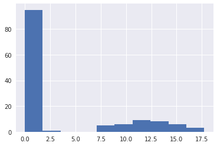

```python
# If you've not yet cleaned the dataset of all NaN values, then investigate and
# do that now.

nans = 100 * df_general.isnull().sum() / df_general.shape[0]
plt.hist(nans,10)
```

```python
imputer = Imputer(missing_values=np.nan)
imputer_model = imputer.fit(df_general)


df_imputed = pd.DataFrame(imputer_model.transform(df_general))
df_imputed.columns = df_general.columns
df_imputed.index = df_general.index
df_imputed.head()
```

|  | ALTERSKATEGORIE_GROB | ANREDE_KZ | FINANZ_MINIMALIST | FINANZ_SPARER | FINANZ_VORSORGER | FINANZ_ANLEGER | FINANZ_UNAUFFAELLIGER | FINANZ_HAUSBAUER | GREEN_AVANTGARDE | HEALTH_TYP | ... | ZABEOTYP_2.0 | ZABEOTYP_3.0 | ZABEOTYP_4.0 | ZABEOTYP_5.0 | ZABEOTYP_6.0 | ZABEOTYP_nan | avantgarde | generation | wealth | life_stage |
| --- | --- | --- | --- | --- | --- | --- | --- | --- | --- | --- | --- | --- | --- | --- | --- | --- | --- | --- | --- | --- | --- |
| 0 | 2.0 | 1.0 | 3.0 | 4.0 | 3.0 | 5.0 | 5.0 | 3.0 | 0.0 | 2.190129 | ... | 0.0 | 1.0 | 0.0 | 0.0 | 0.0 | 0.0 | 0.0 | 4.332805 | 3.262098 | 2.873033 |
| 1 | 1.0 | 2.0 | 1.0 | 5.0 | 2.0 | 5.0 | 4.0 | 5.0 | 0.0 | 3.000000 | ... | 0.0 | 0.0 | 0.0 | 1.0 | 0.0 | 0.0 | 0.0 | 6.000000 | 5.000000 | 1.000000 |
| 2 | 3.0 | 2.0 | 1.0 | 4.0 | 1.0 | 2.0 | 3.0 | 5.0 | 1.0 | 3.000000 | ... | 0.0 | 0.0 | 0.0 | 1.0 | 0.0 | 0.0 | 1.0 | 6.000000 | 2.000000 | 4.000000 |
| 3 | 4.0 | 2.0 | 4.0 | 2.0 | 5.0 | 2.0 | 1.0 | 2.0 | 0.0 | 2.000000 | ... | 0.0 | 1.0 | 0.0 | 0.0 | 0.0 | 0.0 | 0.0 | 4.000000 | 1.000000 | 2.000000 |
| 4 | 3.0 | 1.0 | 4.0 | 3.0 | 4.0 | 1.0 | 3.0 | 2.0 | 0.0 | 3.000000 | ... | 0.0 | 0.0 | 1.0 | 0.0 | 0.0 | 0.0 | 0.0 | 4.000000 | 4.000000 | 3.000000 |

5 rows × 133 columns

```python
# Check the result
df_imputed.isnull().sum().sum()
```

```
0
```

```python
# Apply feature scaling to the general population demographics data.
scaler = StandardScaler()
scaler_model = scaler.fit(df_imputed)
df_scaled = pd.DataFrame(scaler_model.transform(df_imputed))
df_scaled.columns = df_imputed.columns
df_scaled.index = df_imputed.index
df_scaled.head()
```

|  | ALTERSKATEGORIE_GROB | ANREDE_KZ | FINANZ_MINIMALIST | FINANZ_SPARER | FINANZ_VORSORGER | FINANZ_ANLEGER | FINANZ_UNAUFFAELLIGER | FINANZ_HAUSBAUER | GREEN_AVANTGARDE | HEALTH_TYP | ... | ZABEOTYP_2.0 | ZABEOTYP_3.0 | ZABEOTYP_4.0 | ZABEOTYP_5.0 | ZABEOTYP_6.0 | ZABEOTYP_nan | avantgarde | generation | wealth | life_stage |
| --- | --- | --- | --- | --- | --- | --- | --- | --- | --- | --- | --- | --- | --- | --- | --- | --- | --- | --- | --- | --- | --- |
| 0 | -0.750972 | -1.045218 | -0.056416 | 0.804890 | -0.303378 | 1.285741 | 1.429871 | -0.055511 | -0.494701 | 0.000000 | ... | -0.196615 | 1.200973 | -0.555385 | -0.324607 | -0.301964 | 0.0 | -0.494701 | -1.298633e-15 | 3.216984e-16 | 6.346104e-16 |
| 1 | -1.742724 | 0.956738 | -1.570358 | 1.487601 | -1.059731 | 1.285741 | 0.757254 | 1.422415 | -0.494701 | 1.146266 | ... | -0.196615 | -0.832658 | -0.555385 | 3.080647 | -0.301964 | 0.0 | -0.494701 | 1.218829e+00 | 1.258937e+00 | -1.338297e+00 |
| 2 | 0.240781 | 0.956738 | -1.570358 | 0.804890 | -1.816084 | -0.675554 | 0.084637 | 1.422415 | 2.021423 | 1.146266 | ... | -0.196615 | -0.832658 | -0.555385 | 3.080647 | -0.301964 | 0.0 | 2.021423 | 1.218829e+00 | -9.142640e-01 | 8.052265e-01 |
| 3 | 1.232533 | 0.956738 | 0.700556 | -0.560532 | 1.209329 | -0.675554 | -1.260597 | -0.794475 | -0.494701 | -0.269102 | ... | -0.196615 | 1.200973 | -0.555385 | -0.324607 | -0.301964 | 0.0 | -0.494701 | -2.433020e-01 | -1.638664e+00 | -6.237891e-01 |
| 4 | 0.240781 | -1.045218 | 0.700556 | 0.122179 | 0.452976 | -1.329319 | 0.084637 | -0.794475 | -0.494701 | 1.146266 | ... | -0.196615 | -0.832658 | 1.800553 | -0.324607 | -0.301964 | 0.0 | -0.494701 | -2.433020e-01 | 5.345367e-01 | 9.071870e-02 |

5 rows × 133 columns

### Discussion 2.1: Apply Feature Scaling

There's no missing data in most columns and a relatively low amount in the remaining columns. I am going to impute the values for the missing data.

After the imputation, I applied the StandardScaler to the data

### Step 2.2: Perform Dimensionality Reduction

On your scaled data, you are now ready to apply dimensionality reduction techniques.

- Use sklearn's [PCA](http://scikit-learn.org/stable/modules/generated/sklearn.decomposition.PCA.html) class to apply principal component analysis on the data, thus finding the vectors of maximal variance in the data. To start, you should not set any parameters (so all components are computed) or set a number of components that is at least half the number of features (so there's enough features to see the general trend in variability).
- Check out the ratio of variance explained by each principal component as well as the cumulative variance explained. Try plotting the cumulative or sequential values using matplotlib's [`plot()`](https://matplotlib.org/api/_as_gen/matplotlib.pyplot.plot.html) function. Based on what you find, select a value for the number of transformed features you'll retain for the clustering part of the project.
- Once you've made a choice for the number of components to keep, make sure you re-fit a PCA instance to perform the decided-on transformation.

```python
# Apply PCA to the data.
pca = PCA()
df_pca = pca.fit_transform(df_scaled)
```

```python
# Investigate the variance accounted for by each principal component.

# Using code from the "Interpret_PCA_Results" lab for the plotting

def scree_plot(pca):
    '''
    Creates a scree plot associated with the principal components

    INPUT: pca - the result of instantian of PCA in scikit learn

    OUTPUT:
            None
    '''
    num_components = len(pca.explained_variance_ratio_)
    ind = np.arange(num_components)
    vals = pca.explained_variance_ratio_

    plt.figure(figsize=(10, 6))
    ax = plt.subplot(111)
    cumvals = np.cumsum(vals)
    ax.bar(ind, vals)
    ax.plot(ind, cumvals)
    for i in range(num_components):
        ax.annotate(r"%s%%" % ((str(vals[i]*100)[:4])), (ind[i]+0.2, vals[i]), va="bottom", ha="center", fontsize=12)

    ax.xaxis.set_tick_params(width=0)
    ax.yaxis.set_tick_params(width=2, length=12)

    ax.set_xlabel("Principal Component")
    ax.set_ylabel("Variance Explained (%)")
    plt.title('Explained Variance Per Principal Component')
```

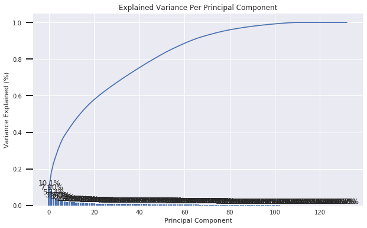

```python
scree_plot(pca)
```

```python
# Re-apply PCA to the data while selecting for number of components to retain.
pca = PCA(n_components=50)
pca_model = pca.fit(df_scaled)

df_pca = pca_model.transform(df_scaled)
df_pca = pd.DataFrame(df_pca)
```

```python
df_pca.head()
```

|  | 0 | 1 | 2 | 3 | 4 | 5 | 6 | 7 | 8 | 9 | ... | 40 | 41 | 42 | 43 | 44 | 45 | 46 | 47 | 48 | 49 |
| --- | --- | --- | --- | --- | --- | --- | --- | --- | --- | --- | --- | --- | --- | --- | --- | --- | --- | --- | --- | --- | --- |
| 0 | 0.903927 | -0.388699 | -1.850381 | 1.027547 | 0.702150 | -1.108037 | 1.145013 | 0.254384 | 1.599953 | -2.383655 | ... | 0.223110 | 0.554743 | 0.113451 | -0.019306 | 0.911164 | 0.124793 | 0.388343 | -0.620635 | 0.045042 | -0.609553 |
| 1 | 5.006648 | -3.917385 | -1.223250 | -1.750022 | -2.437954 | 1.413083 | -0.350315 | -2.603031 | 2.792177 | -0.048722 | ... | -1.725456 | -1.002765 | -0.310527 | -0.961445 | -1.892858 | -0.730685 | -4.164843 | -2.291612 | 1.689754 | -3.461049 |
| 2 | 0.113461 | -0.559029 | -2.013774 | -0.307129 | -2.158728 | -0.650456 | -4.354013 | -1.942139 | 0.199654 | 0.479782 | ... | 0.071810 | -0.312178 | 0.231197 | 1.650999 | -1.319452 | 1.381808 | 0.703675 | -0.197999 | 1.054543 | -1.356669 |
| 3 | -4.513837 | 1.308194 | -2.240773 | -0.708048 | 2.559207 | 0.533436 | 0.937873 | 1.874182 | -0.156681 | -0.014152 | ... | 0.540153 | 1.002205 | -1.395373 | 1.090668 | -0.667726 | 0.498714 | 0.472632 | -1.134913 | -0.920762 | -1.050478 |
| 4 | -0.059834 | 0.780461 | 3.178985 | 2.328908 | -0.530345 | -0.052272 | 3.232646 | -1.907460 | -0.189706 | 0.255679 | ... | 0.157618 | -0.348176 | 0.278443 | 0.108734 | 0.240206 | 0.076146 | 0.152909 | -0.008709 | 0.474814 | 0.155092 |

5 rows × 50 columns

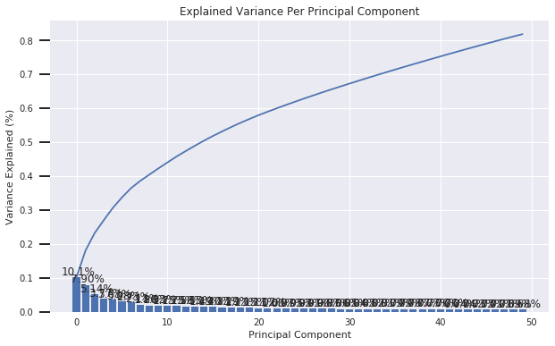

```python
scree_plot(pca)
```

### Discussion 2.2: Perform Dimensionality Reduction

- The scree plot shows that 80% of the variance can be accounted for with around 50 features. I am going to use that number going forward.

### Step 2.3: Interpret Principal Components

Now that we have our transformed principal components, it's a nice idea to check out the weight of each variable on the first few components to see if they can be interpreted in some fashion.

As a reminder, each principal component is a unit vector that points in the direction of highest variance (after accounting for the variance captured by earlier principal components). The further a weight is from zero, the more the principal component is in the direction of the corresponding feature. If two features have large weights of the same sign (both positive or both negative), then increases in one tend expect to be associated with increases in the other. To contrast, features with different signs can be expected to show a negative correlation: increases in one variable should result in a decrease in the other.

- To investigate the features, you should map each weight to their corresponding feature name, then sort the features according to weight. The most interesting features for each principal component, then, will be those at the beginning and end of the sorted list. Use the data dictionary document to help you understand these most prominent features, their relationships, and what a positive or negative value on the principal component might indicate.
- You should investigate and interpret feature associations from the first three principal components in this substep. To help facilitate this, you should write a function that you can call at any time to print the sorted list of feature weights, for the *i*-th principal component. This might come in handy in the next step of the project, when you interpret the tendencies of the discovered clusters.

```python
print(pca.explained_variance_[0])
print(pca.explained_variance_[1])
print(pca.explained_variance_[2])
```

```
13.3033934708
10.3552907322
6.73610651122
```

```python
# Map weights for the first principal component to corresponding feature names
# and then print the linked values, sorted by weight.
# HINT: Try defining a function here or in a new cell that you can reuse in the
# other cells.

def get_sorted_features(columns, component):
    weight_map = dict(zip(columns, component))
    sorted_features = sorted(weight_map.items(), key=operator.itemgetter(1), reverse=True)
    return sorted_features
```

```python
all_cols = list(df_scaled)
pc_1 = pca.components_[0]
features_1 = get_sorted_features(all_cols, pc_1)
features_1
```

```
[('LP_STATUS_GROB_1.0', 0.20124387838221006),
 ('PLZ8_ANTG3', 0.19192523359340166),
 ('PLZ8_ANTG4', 0.18554918299869308),
 ('wealth', 0.18248017688001011),
 ('HH_EINKOMMEN_SCORE', 0.16939426109951022),
 ('ORTSGR_KLS9', 0.16541682729655874),
 ('EWDICHTE', 0.16389570142036436),
 ('FINANZ_HAUSBAUER', 0.15404452046389705),
 ('FINANZ_SPARER', 0.13642913351764416),
 ('KBA05_ANTG4', 0.13307090970087795),
 ('PLZ8_ANTG2', 0.13123526800217436),
 ('LP_STATUS_FEIN_2.0', 0.12801057885339806),
 ('FINANZTYP_1.0', 0.12789897525719576),
 ('LP_STATUS_FEIN_1.0', 0.12582547429209914),
 ('KBA05_ANTG3', 0.12302595025589744),
 ('ANZ_HAUSHALTE_AKTIV', 0.11982555756313597),
 ('ARBEIT', 0.11973442050796665),
 ('RELAT_AB', 0.11315788237909032),
 ('SEMIO_PFLICHT', 0.1021495078550253),
 ('generation', 0.093398113142299594),
 ('SEMIO_REL', 0.09218309659586163),
 ('SEMIO_RAT', 0.086653580096209409),
 ('ZABEOTYP_5.0', 0.085846960742887474),
 ('LP_FAMILIE_FEIN_1.0', 0.085604364877484657),
 ('LP_FAMILIE_GROB_1.0', 0.085604364877484657),
 ('SEMIO_TRADV', 0.075237226927947196),
 ('FINANZ_ANLEGER', 0.072300045069737001),
 ('FINANZ_UNAUFFAELLIGER', 0.06924140912268395),
 ('SEMIO_MAT', 0.064581015263942304),
 ('REGIOTYP', 0.064504352473152782),
 ('GFK_URLAUBERTYP_12.0', 0.062805256358785533),
 ('SEMIO_FAM', 0.060219239692124032),
 ('SEMIO_KULT', 0.050580779564313554),
 ('SEMIO_KAEM', 0.04578483666110722),
 ('ZABEOTYP_4.0', 0.043319363636798884),
 ('W_KEIT_KIND_HH', 0.041266079234216171),
 ('KKK', 0.040653872937619684),
 ('PLZ8_HHZ', 0.037295912625194869),
 ('ZABEOTYP_6.0', 0.035439215079411265),
 ('SEMIO_DOM', 0.031821606884741088),
```

[output cut: 78 more lines]

```
 ('life_stage', -0.10983335613124941),
 ('GREEN_AVANTGARDE', -0.11047853968892576),
 ('avantgarde', -0.11047853968892576),
 ('LP_STATUS_FEIN_9.0', -0.11787065774876712),
 ('LP_STATUS_GROB_4.0', -0.1195613328834292),
 ('LP_STATUS_FEIN_10.0', -0.12072665893581346),
 ('LP_STATUS_GROB_5.0', -0.12072665893581346),
 ('INNENSTADT', -0.13667260742177872),
 ('PLZ8_GBZ', -0.13983920315336956),
 ('KONSUMNAEHE', -0.14148052429824498),
 ('PLZ8_ANTG1', -0.19125894348916134),
 ('KBA05_GBZ', -0.19215204410464073),
 ('KBA05_ANTG1', -0.20154195575890249),
 ('FINANZ_MINIMALIST', -0.21173736972590967),
 ('MOBI_REGIO', -0.21503792241724537)]
```

```python
# Map weights for the second principal component to corresponding feature names
# and then print the linked values, sorted by weight.
features_2 = get_sorted_features(all_cols, pca.components_[1])
features_2
```

```
[('ALTERSKATEGORIE_GROB', 0.22844495045930568),
 ('FINANZ_VORSORGER', 0.22294605371344003),
 ('SEMIO_ERL', 0.17417556924359748),
 ('RETOURTYP_BK_S', 0.16304416121989701),
 ('ZABEOTYP_3.0', 0.16131445654127452),
 ('SEMIO_LUST', 0.15442574157079469),
 ('W_KEIT_KIND_HH', 0.13841742177769167),
 ('LP_STATUS_FEIN_1.0', 0.1183078422752543),
 ('FINANZTYP_5.0', 0.11282029899166861),
 ('CJT_GESAMTTYP_2.0', 0.10846442932090575),
 ('FINANZ_HAUSBAUER', 0.10005054737051176),
 ('FINANZTYP_2.0', 0.09374943248461888),
 ('PLZ8_ANTG3', 0.084928530418382012),
 ('EWDICHTE', 0.082921857620499945),
 ('ORTSGR_KLS9', 0.081980320584046709),
 ('LP_FAMILIE_FEIN_1.0', 0.081887730123482591),
 ('LP_FAMILIE_GROB_1.0', 0.081887730123482591),
 ('PLZ8_ANTG4', 0.080962724266197703),
 ('FINANZ_MINIMALIST', 0.079073247241952901),
 ('HH_EINKOMMEN_SCORE', 0.076880488475606676),
 ('FINANZTYP_6.0', 0.076362179404876385),
 ('CJT_GESAMTTYP_1.0', 0.075003581012513657),
 ('wealth', 0.072356649623658148),
 ('GFK_URLAUBERTYP_4.0', 0.065842655727783042),
 ('KBA05_ANTG4', 0.062828332710989768),
 ('ARBEIT', 0.061961566569743477),
 ('ANZ_HAUSHALTE_AKTIV', 0.059369224564920837),
 ('PLZ8_ANTG2', 0.059209136525024145),
 ('RELAT_AB', 0.059157319103077123),
 ('LP_STATUS_FEIN_3.0', 0.055644240203840262),
 ('WOHNDAUER_2008', 0.052515328101089907),
 ('LP_STATUS_GROB_1.0', 0.048900859131520188),
 ('GFK_URLAUBERTYP_7.0', 0.042706487334940341),
 ('KBA05_ANTG3', 0.040887183746395418),
 ('LP_FAMILIE_FEIN_2.0', 0.039596182564515262),
 ('LP_FAMILIE_GROB_2.0', 0.039596182564515262),
 ('ZABEOTYP_6.0', 0.035363108833797181),
 ('GFK_URLAUBERTYP_3.0', 0.032469725638547893),
 ('SEMIO_KRIT', 0.030506378759460412),
 ('VERS_TYP', 0.02878047347121928),
```

[output cut: 78 more lines]

```
 ('LP_STATUS_FEIN_5.0', -0.09617759419319126),
 ('FINANZTYP_4.0', -0.10562303086907436),
 ('FINANZTYP_1.0', -0.11488929859496808),
 ('SEMIO_FAM', -0.12686784115646596),
 ('SEMIO_MAT', -0.13098646810492084),
 ('SEMIO_KULT', -0.13269804982600919),
 ('ONLINE_AFFINITAET', -0.16207885731154936),
 ('SEMIO_RAT', -0.17482116969054459),
 ('SEMIO_TRADV', -0.19768590579120976),
 ('SEMIO_PFLICHT', -0.20611056083433638),
 ('SEMIO_REL', -0.20742948673085831),
 ('FINANZ_ANLEGER', -0.21722747473268753),
 ('FINANZ_UNAUFFAELLIGER', -0.22096753316652193),
 ('FINANZ_SPARER', -0.23037403228679007),
 ('generation', -0.23672331496361612)]
```

```python
# Map weights for the third principal component to corresponding feature names
# and then print the linked values, sorted by weight.
features_3 = get_sorted_features(all_cols, pca.components_[2])
features_3
```

```
[('SEMIO_VERT', 0.32562276130242906),
 ('SEMIO_KULT', 0.2801317467061627),
 ('SEMIO_SOZ', 0.27720959727477662),
 ('SEMIO_FAM', 0.19221578035090736),
 ('ZABEOTYP_1.0', 0.1274232821279441),
 ('FINANZTYP_5.0', 0.10564412162778829),
 ('FINANZ_MINIMALIST', 0.088641372485873282),
 ('GREEN_AVANTGARDE', 0.082535509434726984),
 ('avantgarde', 0.082535509434726984),
 ('SEMIO_MAT', 0.073935013658428056),
 ('ZABEOTYP_6.0', 0.05906848105842092),
 ('LP_STATUS_FEIN_10.0', 0.058740501600388552),
 ('LP_STATUS_GROB_5.0', 0.058740501600388552),
 ('CJT_GESAMTTYP_4.0', 0.058668579336316244),
 ('SEMIO_TRADV', 0.055471111659753325),
 ('LP_STATUS_FEIN_1.0', 0.053843017339304695),
 ('SEMIO_REL', 0.052831509318957505),
 ('HH_EINKOMMEN_SCORE', 0.050669149358979863),
 ('FINANZTYP_3.0', 0.047741522639718613),
 ('ONLINE_AFFINITAET', 0.047181611185797855),
 ('ORTSGR_KLS9', 0.044812709403275017),
 ('CJT_GESAMTTYP_3.0', 0.044340701381039134),
 ('EWDICHTE', 0.043496964030438012),
 ('LP_FAMILIE_FEIN_1.0', 0.039036704580247814),
 ('LP_FAMILIE_GROB_1.0', 0.039036704580247814),
 ('RETOURTYP_BK_S', 0.038565294789812826),
 ('LP_FAMILIE_GROB_5.0', 0.038135382523448821),
 ('PLZ8_ANTG4', 0.03654667937767879),
 ('PLZ8_ANTG3', 0.034867442095566123),
 ('LP_STATUS_GROB_3.0', 0.034415476810748795),
 ('LP_STATUS_GROB_1.0', 0.034375786831920149),
 ('FINANZTYP_6.0', 0.033628335879834922),
 ('CJT_GESAMTTYP_5.0', 0.032083876792257687),
 ('LP_STATUS_FEIN_6.0', 0.028128991434454024),
 ('ANZ_PERSONEN', 0.027993842319118376),
 ('LP_FAMILIE_FEIN_10.0', 0.027013251851765042),
 ('LP_FAMILIE_FEIN_2.0', 0.02569648129784011),
 ('LP_FAMILIE_GROB_2.0', 0.02569648129784011),
 ('LP_STATUS_FEIN_3.0', 0.025364589812687646),
 ('RELAT_AB', 0.024770970613696684),
```

[output cut: 78 more lines]

```
 ('SEMIO_RAT', -0.096425091503447927),
 ('CJT_GESAMTTYP_6.0', -0.1112161388926739),
 ('GFK_URLAUBERTYP_5.0', -0.11398216006015534),
 ('LP_STATUS_GROB_2.0', -0.11534547214470497),
 ('FINANZTYP_4.0', -0.12368009483591377),
 ('FINANZ_ANLEGER', -0.1459257086175911),
 ('ZABEOTYP_3.0', -0.14689334969398604),
 ('LP_STATUS_FEIN_5.0', -0.15212168026442813),
 ('LP_FAMILIE_FEIN_nan', -0.15570361773717623),
 ('LP_FAMILIE_GROB_nan', -0.15570361773717623),
 ('SEMIO_ERL', -0.16462239183790095),
 ('SEMIO_DOM', -0.27982660493416894),
 ('SEMIO_KRIT', -0.29468722752233412),
 ('ANREDE_KZ', -0.29542063870076951),
 ('SEMIO_KAEM', -0.31245743782391183)]
```

### Discussion 2.3: Interpret Principal Components

- LP_STATUS_GROB_1.0 (0.20124390024672165) (low income earners)
- PLZ8_ANTG3 (0.19192521760953055) (Number of 6-10 family houses)
- PLZ8_ANTG4 (0.1855491332508015) (Number of 10+ family houses)
- wealth (0.18248021731857061) (wealth)

The top features in terms of negative weights are:

- KBA05_GBZ (-0.19215207253971955) (Number of buildings in the microcell)
- KBA05_ANTG1 (-0.20154195583813223) (Number of 1-2 family houses in the microcell)
- FINANZ_MINIMALIST (-0.21173737625698161) (financial type: low financial interest)
- MOBI_REGIO (-0.21503793942469618) (Movement patterns)

- ALTERSKATEGORIE_GROB (0.2284) (Estimated age)
- FINANZ_VORSORGER (0.2229) (Financial typology: Be prepared)
- SEMIO_ERL (0.1741) (personality type: event-oriented)
- RETOURTYP_BK_S (0.1630) (return type)

The top features in terms of negative weights are:

- FINANZ_ANLEGER (-0.2172) (financial type: investor)
- FINANZ_UNAUFFAELLIGER (-0.2209) (financial type: inconspicuous)
- FINANZ_SPARER (-0.2303) (financial type: money-saver)
- generation (-0.2367) (generation of youth)

- SEMIO_VERT (0.3256) (personality type: dreamful)
- SEMIO_KULT (0.2801) (personality type: cultural-minded)
- SEMIO_SOZ (0.2772) (personality type: socially-minded)
- SEMIO_FAM (0.1922) (personality type: family-minded)

The top features in terms of negative weights are:

- SEMIO_DOM (-0.2798) (personality type: dominant-minded)
- SEMIO_KRIT (-0.2946) (personality type: critical-minded
- ANREDE_KZ (-0.2954) (gender)
- SEMIO_KAEM (-0.3124) (personality type: combative attitude)

##### Discussion

The first component is a combination of features pointing at low income earners. There is that feature specifically, but also related features indicating large buildings holding 10 families. The wealth feature is also represented. The negative weights show an influence by small, single family houses and by low financial interest. This makes sense because the large positive weights are negatively correlated with the negative weights.

The second component is influenced by a 'be prepared' financial philosophy, but also age, and personality and return shopper types. The negative weights are all related to a conservative financial philosophy.

The third component is all about personaility features, with the positive weights all pointing to a open, social, creative personality, and the negatvie to a more reserved, combative personality.

## Step 3: Clustering

### Step 3.1: Apply Clustering to General Population

You've assessed and cleaned the demographics data, then scaled and transformed them. Now, it's time to see how the data clusters in the principal components space. In this substep, you will apply k-means clustering to the dataset and use the average within-cluster distances from each point to their assigned cluster's centroid to decide on a number of clusters to keep.

- Use sklearn's KMeans class to perform k-means clustering on the PCA-transformed data.
- Then, compute the average difference from each point to its assigned cluster's center. **Hint**: The KMeans object's `.score()` method might be useful here, but note that in sklearn, scores tend to be defined so that larger is better. Try applying it to a small, toy dataset, or use an internet search to help your understanding.
- Perform the above two steps for a number of different cluster counts. You can then see how the average distance decreases with an increasing number of clusters. However, each additional cluster provides a smaller net benefit. Use this fact to select a final number of clusters in which to group the data. **Warning**: because of the large size of the dataset, it can take a long time for the algorithm to resolve. The more clusters to fit, the longer the algorithm will take. You should test for cluster counts through at least 10 clusters to get the full picture, but you shouldn't need to test for a number of clusters above about 30.
- Once you've selected a final number of clusters to use, re-fit a KMeans instance to perform the clustering operation. Make sure that you also obtain the cluster assignments for the general demographics data, since you'll be using them in the final Step 3.3.

```python
def compute_distances(labels, cluster_distances):
    num_centers = cluster_distances.shape[1]
    sum_distances = np.zeros((1, num_centers))
    for i, point_label in enumerate(labels):
        distance = cluster_distances[i][point_label]
        sum_distances[0][point_label] += distance
    mean_distances = sum_distances/labels.shape[0]
    return mean_distances
```

```python
# Over a number of different cluster counts...
cluster_range = [4,8,10,20,30,35,40]
cluster_means = []
for cluster_num in cluster_range:
    print("{} clusters".format(cluster_num))
    kmeans = KMeans(n_clusters=cluster_num)
    model = kmeans.fit(df_pca)
    labels = kmeans.predict(df_pca)
    cluster_distance_space = model.transform(df_pca)

    mean_distances = compute_distances(labels, cluster_distance_space)
    cluster_means.append(mean_distances.mean())


print(cluster_means)
```

```
4 clusters
8 clusters
10 clusters
20 clusters
30 clusters
35 clusters
40 clusters
[2.2868879565234757, 1.0357112981181738, 0.81199477015636956, 0.3802928889488314, 0.2426833351356765, 0.20468673784076505, 0.17662788816011429]
```

```python
# Investigate the change in within-cluster distance across number of clusters.
# HINT: Use matplotlib's plot function to visualize this relationship.

#code for plot modified from 'Changing K' lesson
def plot_k(centers, distances):
    plt.plot(centers, distances, linestyle='--', marker='o', color='b');
    plt.xlabel('K');
    plt.ylabel('Distance');
    plt.title('Mean Distance vs. K');
```

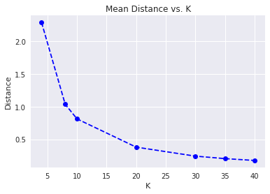

```python
plot_k(cluster_range, cluster_means)
```

```python
kmeans_25 = KMeans(n_clusters=25)
model_25 = kmeans_25.fit(df_pca)
labels_25 = model_25.predict(df_pca)
```

### Step 3.2: Apply All Steps to the Customer Data

Now that you have clusters and cluster centers for the general population, it's time to see how the customer data maps on to those clusters. Take care to not confuse this for re-fitting all of the models to the customer data. Instead, you're going to use the fits from the general population to clean, transform, and cluster the customer data. In the last step of the project, you will interpret how the general population fits apply to the customer data.

- Don't forget when loading in the customers data, that it is semicolon (`;`) delimited.
- Apply the same feature wrangling, selection, and engineering steps to the customer demographics using the `clean_data()` function you created earlier. (You can assume that the customer demographics data has similar meaning behind missing data patterns as the general demographics data.)
- Use the sklearn objects from the general demographics data, and apply their transformations to the customers data. That is, you should not be using a `.fit()` or `.fit_transform()` method to re-fit the old objects, nor should you be creating new sklearn objects! Carry the data through the feature scaling, PCA, and clustering steps, obtaining cluster assignments for all of the data in the customer demographics data.

```python
# Load in the customer demographics data.
customers = pd.read_csv('./Udacity_CUSTOMERS_Subset.csv',sep=';')
customers.head()
```

|  | AGER_TYP | ALTERSKATEGORIE_GROB | ANREDE_KZ | CJT_GESAMTTYP | FINANZ_MINIMALIST | FINANZ_SPARER | FINANZ_VORSORGER | FINANZ_ANLEGER | FINANZ_UNAUFFAELLIGER | FINANZ_HAUSBAUER | ... | PLZ8_ANTG1 | PLZ8_ANTG2 | PLZ8_ANTG3 | PLZ8_ANTG4 | PLZ8_BAUMAX | PLZ8_HHZ | PLZ8_GBZ | ARBEIT | ORTSGR_KLS9 | RELAT_AB |
| --- | --- | --- | --- | --- | --- | --- | --- | --- | --- | --- | --- | --- | --- | --- | --- | --- | --- | --- | --- | --- | --- |
| 0 | 2 | 4 | 1 | 5.0 | 5 | 1 | 5 | 1 | 2 | 2 | ... | 3.0 | 3.0 | 1.0 | 0.0 | 1.0 | 5.0 | 5.0 | 1.0 | 2.0 | 1.0 |
| 1 | -1 | 4 | 1 | NaN | 5 | 1 | 5 | 1 | 3 | 2 | ... | NaN | NaN | NaN | NaN | NaN | NaN | NaN | NaN | NaN | NaN |
| 2 | -1 | 4 | 2 | 2.0 | 5 | 1 | 5 | 1 | 4 | 4 | ... | 2.0 | 3.0 | 3.0 | 1.0 | 3.0 | 3.0 | 2.0 | 3.0 | 5.0 | 3.0 |
| 3 | 1 | 4 | 1 | 2.0 | 5 | 1 | 5 | 2 | 1 | 2 | ... | 3.0 | 2.0 | 1.0 | 0.0 | 1.0 | 3.0 | 4.0 | 1.0 | 3.0 | 1.0 |
| 4 | -1 | 3 | 1 | 6.0 | 3 | 1 | 4 | 4 | 5 | 2 | ... | 2.0 | 4.0 | 2.0 | 1.0 | 2.0 | 3.0 | 3.0 | 3.0 | 5.0 | 1.0 |

5 rows × 85 columns

```python
customers.shape
```

```
(191652, 85)
```

```python
# Apply preprocessing, feature transformation, and clustering from the general
# demographics onto the customer data, obtaining cluster predictions for the
# customer demographics data.

def transform(df, imputerer, scalerer, pca, kmeans):
    df_imputed = pd.DataFrame(imputerer.transform(df))
    df_scaled = pd.DataFrame(scalerer.transform(df_imputed))
    df_pca = pca.transform(df_scaled)
    labels = kmeans.predict(df_pca)
    return labels
```

```python
customers = pd.read_csv('./Udacity_CUSTOMERS_Subset.csv',sep=';')
df_customers = clean_data(customers)
customer_labels = transform(df_customers, imputer_model, scaler_model, pca_model, model_25)
```

### Step 3.3: Compare Customer Data to Demographics Data

At this point, you have clustered data based on demographics of the general population of Germany, and seen how the customer data for a mail-order sales company maps onto those demographic clusters. In this final substep, you will compare the two cluster distributions to see where the strongest customer base for the company is.

Consider the proportion of persons in each cluster for the general population, and the proportions for the customers. If we think the company's customer base to be universal, then the cluster assignment proportions should be fairly similar between the two. If there are only particular segments of the population that are interested in the company's products, then we should see a mismatch from one to the other. If there is a higher proportion of persons in a cluster for the customer data compared to the general population (e.g. 5% of persons are assigned to a cluster for the general population, but 15% of the customer data is closest to that cluster's centroid) then that suggests the people in that cluster to be a target audience for the company. On the other hand, the proportion of the data in a cluster being larger in the general population than the customer data (e.g. only 2% of customers closest to a population centroid that captures 6% of the data) suggests that group of persons to be outside of the target demographics.

Take a look at the following points in this step:

- Compute the proportion of data points in each cluster for the general population and the customer data. Visualizations will be useful here: both for the individual dataset proportions, but also to visualize the ratios in cluster representation between groups. Seaborn's [`countplot()`](https://seaborn.pydata.org/generated/seaborn.countplot.html) or [`barplot()`](https://seaborn.pydata.org/generated/seaborn.barplot.html) function could be handy.
  - Recall the analysis you performed in step 1.1.3 of the project, where you separated out certain data points from the dataset if they had more than a specified threshold of missing values. If you found that this group was qualitatively different from the main bulk of the data, you should treat this as an additional data cluster in this analysis. Make sure that you account for the number of data points in this subset, for both the general population and customer datasets, when making your computations!
- Which cluster or clusters are overrepresented in the customer dataset compared to the general population? Select at least one such cluster and infer what kind of people might be represented by that cluster. Use the principal component interpretations from step 2.3 or look at additional components to help you make this inference. Alternatively, you can use the `.inverse_transform()` method of the PCA and StandardScaler objects to transform centroids back to the original data space and interpret the retrieved values directly.
- Perform a similar investigation for the underrepresented clusters. Which cluster or clusters are underrepresented in the customer dataset compared to the general population, and what kinds of people are typified by these clusters?

```python
# Compare the proportion of data in each cluster for the customer data to the
# proportion of data in each cluster for the general population.
count_general_map = Counter(labels_25)
count_customer_map = Counter(customer_labels)

counts_customer = np.zeros((1, 25))
counts_general = np.zeros((1,25))
for i in range(0,25):
    counts_customer[0][i] = count_customer_map.get(i)
    counts_general[0][i] = count_general_map.get(i)


props_general = 100 * counts_general / labels_25.shape[0]
props_customer = 100 * counts_customer / customer_labels.shape[0]
```

```python
data_general = {'value':props_general[0], 'cluster':range(0,25), 'population':'general'}
data_customer = {'value':props_customer[0], 'cluster':range(0,25), 'population':'customer'}
index = range(0,25)
general = pd.DataFrame(data=data_general, index=index)
customer = pd.DataFrame(data=data_customer, index=index)
df_chart = pd.concat([general,customer])
df_chart.head()
```

|  | cluster | population | value |
| --- | --- | --- | --- |
| 0 | 0 | general | 1.246604 |
| 1 | 1 | general | 5.146198 |
| 2 | 2 | general | 5.239441 |
| 3 | 3 | general | 2.976030 |
| 4 | 4 | general | 7.509249 |

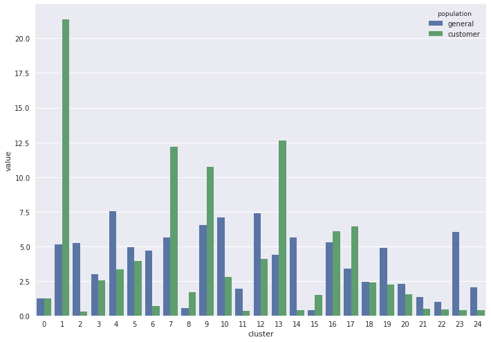

```python
dims = (11.7, 8.27)
fig, ax = plt.subplots(figsize=dims)
sns.set(style="darkgrid")
sns.barplot(x="cluster", y="value", hue="population", data=df_chart, ax=ax)
```

##### Discussion

- As the chart shows, clusters 1 and 13 are over represented in the customer data.
- Clusters 14, and 23 stand out as being underrepresented in the customer data.

```python
def get_responses(centroid, columns):
    full_coords = pca.inverse_transform(centroid)
    orig_values = scaler_model.inverse_transform(full_coords)
    responses = dict(zip(columns,orig_values))
    for key in responses:
        responses[key] = int(responses.get(key))
    return responses
```

```python
# What kinds of people are part of a cluster that is overrepresented in the
# customer data compared to the general population?
centroid_1 = model_25.cluster_centers_[1]
centroid_13 = model_25.cluster_centers_[13]
all_cols = list(df_customers)
```

```python
responses = get_responses(centroid_1, all_cols)
responses
```

```
{'ALTERSKATEGORIE_GROB': 2,
 'ANREDE_KZ': 1,
 'ANZ_HAUSHALTE_AKTIV': 8,
 'ANZ_HH_TITEL': 0,
 'ANZ_PERSONEN': 1,
 'ANZ_TITEL': 0,
 'ARBEIT': 3,
 'BALLRAUM': 4,
 'CJT_GESAMTTYP_1.0': 0,
 'CJT_GESAMTTYP_2.0': 0,
 'CJT_GESAMTTYP_3.0': 0,
 'CJT_GESAMTTYP_4.0': 0,
 'CJT_GESAMTTYP_5.0': 0,
 'CJT_GESAMTTYP_6.0': 1,
 'CJT_GESAMTTYP_nan': 0,
 'EWDICHTE': 3,
 'FINANZTYP_1.0': 0,
 'FINANZTYP_2.0': 0,
 'FINANZTYP_3.0': 0,
 'FINANZTYP_4.0': 1,
 'FINANZTYP_5.0': 0,
 'FINANZTYP_6.0': 0,
 'FINANZTYP_nan': 0,
 'FINANZ_ANLEGER': 5,
 'FINANZ_HAUSBAUER': 3,
 'FINANZ_MINIMALIST': 2,
 'FINANZ_SPARER': 4,
 'FINANZ_UNAUFFAELLIGER': 5,
 'FINANZ_VORSORGER': 2,
 'GEBAEUDETYP_RASTER': 3,
 'GFK_URLAUBERTYP_1.0': 0,
 'GFK_URLAUBERTYP_10.0': 0,
 'GFK_URLAUBERTYP_11.0': 0,
 'GFK_URLAUBERTYP_12.0': 0,
 'GFK_URLAUBERTYP_2.0': 0,
 'GFK_URLAUBERTYP_3.0': 0,
 'GFK_URLAUBERTYP_4.0': 0,
 'GFK_URLAUBERTYP_5.0': 1,
 'GFK_URLAUBERTYP_6.0': 0,
 'GFK_URLAUBERTYP_7.0': 0,
```

[output cut: 78 more lines]

```
 'SOHO_KZ': 0,
 'VERS_TYP': 1,
 'WOHNDAUER_2008': 7,
 'W_KEIT_KIND_HH': 4,
 'ZABEOTYP_1.0': 0,
 'ZABEOTYP_2.0': 0,
 'ZABEOTYP_3.0': 1,
 'ZABEOTYP_4.0': 0,
 'ZABEOTYP_5.0': 0,
 'ZABEOTYP_6.0': 0,
 'ZABEOTYP_nan': 0,
 'avantgarde': 0,
 'generation': 4,
 'life_stage': 2,
 'wealth': 3}
```

```python
responses = get_responses(centroid_13, all_cols)
responses
```

```
{'ALTERSKATEGORIE_GROB': 3,
 'ANREDE_KZ': 1,
 'ANZ_HAUSHALTE_AKTIV': 1,
 'ANZ_HH_TITEL': 0,
 'ANZ_PERSONEN': 3,
 'ANZ_TITEL': 0,
 'ARBEIT': 2,
 'BALLRAUM': 4,
 'CJT_GESAMTTYP_1.0': 0,
 'CJT_GESAMTTYP_2.0': 0,
 'CJT_GESAMTTYP_3.0': 0,
 'CJT_GESAMTTYP_4.0': 0,
 'CJT_GESAMTTYP_5.0': 0,
 'CJT_GESAMTTYP_6.0': 0,
 'CJT_GESAMTTYP_nan': 0,
 'EWDICHTE': 3,
 'FINANZTYP_1.0': 0,
 'FINANZTYP_2.0': 0,
 'FINANZTYP_3.0': 0,
 'FINANZTYP_4.0': 0,
 'FINANZTYP_5.0': 0,
 'FINANZTYP_6.0': 0,
 'FINANZTYP_nan': 0,
 'FINANZ_ANLEGER': 2,
 'FINANZ_HAUSBAUER': 1,
 'FINANZ_MINIMALIST': 4,
 'FINANZ_SPARER': 2,
 'FINANZ_UNAUFFAELLIGER': 2,
 'FINANZ_VORSORGER': 3,
 'GEBAEUDETYP_RASTER': 4,
 'GFK_URLAUBERTYP_1.0': 0,
 'GFK_URLAUBERTYP_10.0': 0,
 'GFK_URLAUBERTYP_11.0': 0,
 'GFK_URLAUBERTYP_12.0': 0,
 'GFK_URLAUBERTYP_2.0': 0,
 'GFK_URLAUBERTYP_3.0': 0,
 'GFK_URLAUBERTYP_4.0': 0,
 'GFK_URLAUBERTYP_5.0': 0,
 'GFK_URLAUBERTYP_6.0': 0,
 'GFK_URLAUBERTYP_7.0': 0,
```

[output cut: 78 more lines]

```
 'SOHO_KZ': 0,
 'VERS_TYP': 1,
 'WOHNDAUER_2008': 8,
 'W_KEIT_KIND_HH': 2,
 'ZABEOTYP_1.0': 0,
 'ZABEOTYP_2.0': 0,
 'ZABEOTYP_3.0': 0,
 'ZABEOTYP_4.0': 0,
 'ZABEOTYP_5.0': 0,
 'ZABEOTYP_6.0': 0,
 'ZABEOTYP_nan': 0,
 'avantgarde': 0,
 'generation': 4,
 'life_stage': 3,
 'wealth': 2}
```

| Feature | cluster 1 val | Translation | cluster 13 val | Translation |  |
| --- | --- | --- | --- | --- | --- |
| ALTERSKATEGORIE_GROB | 2 | 30 - 45 years old | 3 | 46 - 60 years old |  |
| ANREDE_KZ | 1 | male | 1 | **SAME** |  |
| ANZ_HAUSHALTE_AKTIV | 8 | Number of households in the building | 1 |  |  |
| ANZ_HH_TITEL | 0 | Number of professional academic title holders in building | 0 | **SAME** |  |
| ANZ_PERSONEN | 1 | Number of adults in household | 3 |  |  |
| ANZ_TITEL | 0 | Number of professional academic title holders in household | 0 | **SAME** |  |
| ARBEIT | 3 | Share of unemployment in community: average | 2 | low |  |
| BALLRAUM | 4 | Distance to nearest urban center: 30-40km | 4 | **SAME** |  |
| CJT_GESAMTTYP |  | Advertising-Enthusiast with restricted Cross-Channel-Behaviour | na |  |  |
| EWDICHTE | 3 | 90 - 149 households per km^2 | 3 | **SAME** |  |
| FINANZTYP |  | be prepared (VORSORGER) | no answer |  |  |
| FINANZ |  | dimension: low financial interest, be prepared, does not save |  | investor, saver, home owner, is interested in finances |  |
| GEBAEUDETYP_RASTER | 3 | mixed cell with middle business share | 4 | mixed cell with low business share |  |
| GFK_URLAUBERTYP_5.0 | 1 | Nature fans | na |  |  |
| GREEN_AVANTGARDE | 0 | not a greener | 0 | **SAME** |  |
| HEALTH_TYP | 2 | sanitary affine | 2 | **SAME** |  |
| HH_EINKOMMEN_SCORE | 1 | highest income | 2 | very high income |  |
| INNENSTADT | 4 | 5 - 10 km to city center | 4 | **SAME** |  |
| KBA05_ANTG1 | 1 | lower share of 1-2 family homes | 2 | average share of 1-2 family homes |  |
| KBA05_ANTG2 | 1 | lower share of 3-5 family homes | 1 | **SAME** |  |
| KBA05_ANTG3 | 0 | no 6-10 family homes | 0 | **SAME** |  |
| KBA05_ANTG4 | 0 | no 10+ family homes | 0 | **SAME** |  |
| KBA05_GBZ | 3 | 5-16 buildings in microcell | 4 | 17-22 buildings |  |
| KBA13_ANZAHL_PKW | 621 | Number of cars in the PLZ8 region | 699 |  |  |
| KKK | 2 | Purchasing power in region: High | 2 | **SAME** |  |
| KONSUMNAEHE | 3 | Distance from building to point of sale (PoS) | 3 | **SAME** |  |
| LP_FAMILIE_GROB_nan | 1 | familly type (unknown) | na |  |  |
| MIN_GEBAEUDEJAHR | 1993 | first year of buildling mention | 1993 | **SAME** |  |
| MOBI_REGIO | 2 | high movement patterns | 4 | low movement |  |
| ONLINE_AFFINITAET | 2 | middle online affinity | 3 | high |  |
| ORTSGR_KLS9 | 5 | size of community: 20,001 to 50,000 inhabitants | 5 | **SAME** |  |
| OST_WEST_KZ | 0 | Building location:former east ger | 0 | **SAME** |  |
| PLZ8_ANTG1 | 2 | average share of 1-2 family homes | 2 | **SAME** |  |
| PLZ8_ANTG2 | 2 | average share of 3-5 family homes | 2 | **SAME** |  |
| PLZ8_ANTG3 | 1 | lower share of 6-10 family homes | 1 | **SAME** |  |
| PLZ8_ANTG4 | 0 | no 10+ family homes | 0 | **SAME** |  |
| PLZ8_GBZ | 3 | buildings in region: 130-299 buildings | 3 | **SAME** |  |
| PLZ8_HHZ | 3 | households in region: 300-599 households | 3 | **SAME** |  |
| REGIOTYP | 4 | region type: middle class | 3 | upper middle class |  |
| RELAT_AB | 3 | unemployment: average | 2 | low |  |
| RETOURTYP_BK_S | 2 | demanding Heavy-Returner | 4 | conservative Low-Returner |  |
| SEMIO_DOM | 5 | dominant-minded: low affinity | 4 | average affinity |  |
| SEMIO_ERL | 3 | event-oriented: high affinity | 4 | average affinity |  |
| SEMIO_FAM | 5 | family-minded: low affinity | 3 | high affinity |  |
| SEMIO_KAEM | 5 | combative attitude: low affinity | 4 | average affinity |  |
| SEMIO_KRIT | 6 | critical-minded: very low affinity | 4 | average affinity |  |
| SEMIO_KULT | 3 | cultural-minded: high affinity | 3 | **SAME** |  |
| SEMIO_LUST | 5 | sensual-minded: low affinity | 4 | average affinity |  |
| SEMIO_MAT | 4 | materialistic: average affinity | 3 | high affinity |  |
| SEMIO_PFLICHT | 5 | dutiful: low affinity | 3 | high affinity |  |
| SEMIO_RAT | 4 | rational: average affinity | 3 | high affinity |  |
| SEMIO_REL | 6 | religious: very low affinity | 3 | high affinity |  |
| SEMIO_SOZ | 1 | socially-minded: highest affinity | 4 | average affinity |  |
| SEMIO_TRADV | 2 | traditional-minded: very high affinity | 3 | high affinity |  |
| SEMIO_VERT | 1 | dreamful: highest affinity | 4 | average affinity |  |
| SOHO_KZ | 0 | no small office/home office | 0 | **SAME** |  |
| VERS_TYP | 1 | social-safety driven | 1 | **SAME** |  |
| WOHNDAUER_2008 | 7 | length of residence 6-7 years | 8 | length of residence 7-10 years |  |
| W_KEIT_KIND_HH | 4 | Likelihood of children in household: average | 2 | very likely |  |
| ZABEOTYP_3.0 | 1 | Energy consumption typology: Fair supplied | na |  |  |
| avantgarde | 0 | mainstream | 0 | **SAME** |  |
| generation | 4 | seventies | 4 | **SAME** |  |
| life_stage | 2 | young couples with children | 3 | families with school age children |  |
| wealth | 3 | comfortable | 2 | prosperous |  |

```python
# What kinds of people are part of a cluster that is underrepresented in the
# customer data compared to the general population?
centroid_14 = model_25.cluster_centers_[14]
centroid_23 = model_25.cluster_centers_[23]
responses = get_responses(centroid_23, all_cols)
responses
```

```
{'ALTERSKATEGORIE_GROB': 1,
 'ANREDE_KZ': 0,
 'ANZ_HAUSHALTE_AKTIV': 16,
 'ANZ_HH_TITEL': 0,
 'ANZ_PERSONEN': 1,
 'ANZ_TITEL': 0,
 'ARBEIT': 3,
 'BALLRAUM': 3,
 'CJT_GESAMTTYP_1.0': 0,
 'CJT_GESAMTTYP_2.0': 0,
 'CJT_GESAMTTYP_3.0': 0,
 'CJT_GESAMTTYP_4.0': 0,
 'CJT_GESAMTTYP_5.0': 0,
 'CJT_GESAMTTYP_6.0': 0,
 'CJT_GESAMTTYP_nan': 0,
 'EWDICHTE': 5,
 'FINANZTYP_1.0': 0,
 'FINANZTYP_2.0': 0,
 'FINANZTYP_3.0': 0,
 'FINANZTYP_4.0': 0,
 'FINANZTYP_5.0': 0,
 'FINANZTYP_6.0': 0,
 'FINANZTYP_nan': 0,
 'FINANZ_ANLEGER': 3,
 'FINANZ_HAUSBAUER': 3,
 'FINANZ_MINIMALIST': 1,
 'FINANZ_SPARER': 4,
 'FINANZ_UNAUFFAELLIGER': 3,
 'FINANZ_VORSORGER': 1,
 'GEBAEUDETYP_RASTER': 3,
 'GFK_URLAUBERTYP_1.0': 0,
 'GFK_URLAUBERTYP_10.0': 0,
 'GFK_URLAUBERTYP_11.0': 0,
 'GFK_URLAUBERTYP_12.0': 0,
 'GFK_URLAUBERTYP_2.0': 0,
 'GFK_URLAUBERTYP_3.0': 0,
 'GFK_URLAUBERTYP_4.0': 0,
 'GFK_URLAUBERTYP_5.0': 0,
 'GFK_URLAUBERTYP_6.0': 0,
 'GFK_URLAUBERTYP_7.0': 0,
```

[output cut: 78 more lines]

```
 'SOHO_KZ': 0,
 'VERS_TYP': 1,
 'WOHNDAUER_2008': 6,
 'W_KEIT_KIND_HH': 4,
 'ZABEOTYP_1.0': 0,
 'ZABEOTYP_2.0': 0,
 'ZABEOTYP_3.0': 0,
 'ZABEOTYP_4.0': 0,
 'ZABEOTYP_5.0': 0,
 'ZABEOTYP_6.0': 0,
 'ZABEOTYP_nan': 0,
 'avantgarde': 0,
 'generation': 5,
 'life_stage': 2,
 'wealth': 4}
```

```python
responses = get_responses(centroid_14, all_cols)
responses
```

```
{'ALTERSKATEGORIE_GROB': 1,
 'ANREDE_KZ': 1,
 'ANZ_HAUSHALTE_AKTIV': 18,
 'ANZ_HH_TITEL': 0,
 'ANZ_PERSONEN': 1,
 'ANZ_TITEL': 0,
 'ARBEIT': 3,
 'BALLRAUM': 2,
 'CJT_GESAMTTYP_1.0': 0,
 'CJT_GESAMTTYP_2.0': 0,
 'CJT_GESAMTTYP_3.0': 0,
 'CJT_GESAMTTYP_4.0': 0,
 'CJT_GESAMTTYP_5.0': 0,
 'CJT_GESAMTTYP_6.0': 0,
 'CJT_GESAMTTYP_nan': 0,
 'EWDICHTE': 5,
 'FINANZTYP_1.0': 0,
 'FINANZTYP_2.0': 0,
 'FINANZTYP_3.0': 0,
 'FINANZTYP_4.0': 0,
 'FINANZTYP_5.0': 0,
 'FINANZTYP_6.0': 0,
 'FINANZTYP_nan': 0,
 'FINANZ_ANLEGER': 4,
 'FINANZ_HAUSBAUER': 4,
 'FINANZ_MINIMALIST': 1,
 'FINANZ_SPARER': 4,
 'FINANZ_UNAUFFAELLIGER': 3,
 'FINANZ_VORSORGER': 2,
 'GEBAEUDETYP_RASTER': 3,
 'GFK_URLAUBERTYP_1.0': 0,
 'GFK_URLAUBERTYP_10.0': 0,
 'GFK_URLAUBERTYP_11.0': 0,
 'GFK_URLAUBERTYP_12.0': 0,
 'GFK_URLAUBERTYP_2.0': 0,
 'GFK_URLAUBERTYP_3.0': 0,
 'GFK_URLAUBERTYP_4.0': 0,
 'GFK_URLAUBERTYP_5.0': 0,
 'GFK_URLAUBERTYP_6.0': 0,
 'GFK_URLAUBERTYP_7.0': 0,
```

[output cut: 78 more lines]

```
 'SOHO_KZ': 0,
 'VERS_TYP': 1,
 'WOHNDAUER_2008': 7,
 'W_KEIT_KIND_HH': 4,
 'ZABEOTYP_1.0': 0,
 'ZABEOTYP_2.0': 0,
 'ZABEOTYP_3.0': 0,
 'ZABEOTYP_4.0': 0,
 'ZABEOTYP_5.0': 0,
 'ZABEOTYP_6.0': 0,
 'ZABEOTYP_nan': 0,
 'avantgarde': 0,
 'generation': 5,
 'life_stage': 1,
 'wealth': 4}
```

[output not shown]

##### Section 1.1.3 analysis

- FINANZTYPE: 4 (be prepared (VORSORGER))
- FINANZ_MINIMALIST: 3 (low financial interest = average)
- SEMIO_RAT: 4 (rational personality dimension: average affinity)

In the code below I compute what proportion of these types are in the general demographics data and the customer data.

```python
def proportion_in_cluster(df):
    # Get the subset missing 10% or more responses
    df_reduced = df[df.isnull().sum(axis=1)>=10]
    count = df_reduced[(df_reduced['FINANZTYP_4.0']==1) & (df_reduced['FINANZ_MINIMALIST']==3) & (df_reduced['SEMIO_RAT']==4)].shape[0]
    prop = 100 * count/df.shape[0]
    return prop

cluster_prop_general = proportion_in_cluster(df_general)
cluster_prop_customers = proportion_in_cluster(df_customers)
```

```python
print(cluster_prop_general)
print(cluster_prop_customers)
```

```
8.301532392077835
24.315947655124916
```

### Discussion 3.3: Compare Customer Data to Demographics Data

Analysis of the dataset revealed 50 principle components to cluster by, and the clustering task identified 25 useful, unique clusters.

I looked at two clusters that stood out as particularly over-represented in the customer data. These clusters had these features in common:

- Members are of the 70's generation
- Male, with kids
- Affluent
- Live in the suburbs of the former East Germany
- Similar psychological traits. Rate high on
  - Culture
  - Tradition

Two clusters that stood out as being *under-represented* in the customer data included these traits:

- Eighties generation, so a younger group than the over-represented people
- Not financially aware or involved
- Most likely not homeowners
- Lower income
- More likely to live in large apartment buildings in the former East Germany
- Similarly low affinity for these psychological traits:
  - Religious
  - Traditional
  - Dutiful

Based on my analysis, I believe the direct marketing campaign should focus on older (35+) males with families and a high income, living in the suburbs of cities in the former East Germany.

> Congratulations on making it this far in the project! Before you finish, make sure to check through the entire notebook from top to bottom to make sure that your analysis follows a logical flow and all of your findings are documented in **Discussion** cells. Once you've checked over all of your work, you should export the notebook as an HTML document to submit for evaluation. You can do this from the menu, navigating to **File -> Download as -> HTML (.html)**. You will submit both that document and this notebook for your project submission.